# Proyecto de Transcritómica - UAM - 2019/2020

Álvaro Huertas García

Universidad Autonoma de Madrid (UAM)

3 junio 2020

#### Abstract

Proyecto de Transcriptómica del Máster en Bioinformática y Biología Computacional de la UAM

# 1 Cargamos las librerías

```r
# Load required libraries

suppressPackageStartupMessages({
library("BiocStyle")
library("affy")
library("limma")
library("genefilter")
library("hgu133plus2.db")
library("calibrate")
library("ArrayTools")})
```

# 2 Diseño del trabajo de análisis

## 2.1 Diseño del análisis

Para el trabajo será interesante realizar dos tipos de estudios:

**1. Podemos analizar las dos líneas por separado y ver si sacamos los mismos resultados, lo que indicaría que las dos líneas celulares son equivalentes, pero si salen resultados diferentes podemos concluir que son líneas independientes**

**2. Podemos juntar las dos líneas celulares y comparar simplemente el efecto de los tratamientos DMSO y SAMH1.** Aquí estaríamos comprobando si hay un efecto o patrón común en ambas líneas celulares.

Primero veremos si hay grandes diferencias entre los controles KOPT-K1_DMSO y HPB-ALL_DMSO. Esto es un estudio inicial para ver si ya se observan diferencias entre ambas líneas celulares. $\rightarrow$ $H_{0}:$ las dos líneas celulares son iguales. Vemos boxplot y distribución de intensidades. Normalizamos. Análisis de expresión diferencial. Ver si hay diferencias.

Tras la aproximación inicial en la que vemos si las líneas celulares son iguales o no hacemos el estudio independiente.

# 3 Comparación controles

## 3.1 Cargamos los ficheros .CEL y extraemos el raw data

Los ficheros control son:

- KOPT-K1_DMSO $\rightarrow$ “GSM455115.CEL”, “GSM455116.CEL”, “GSM455117.CEL”
- HPB-ALL_DMSO $\rightarrow$ “GSM455118.CEL”, “GSM455119.CEL”, “GSM455120.CEL”

```r
# Read .CEL files
# data <- ReadAffy(filenames=targets$FileName)
CELfiles_control <- c("GSM455115.CEL", "GSM455116.CEL", "GSM455117.CEL", "GSM455118.CEL", "GSM455119.CEL", "GSM455120.CEL")

rawdata_control <- ReadAffy(filenames = CELfiles_control)
rawdata_control
```

```
## AffyBatch object
## size of arrays=1164x1164 features (20 kb)
## cdf=HG-U133_Plus_2 (54675 affyids)
## number of samples=6
## number of genes=54675
## annotation=hgu133plus2
## notes=
```

## 3.2 Análisis exploratorio de la calidad de los datos iniciales

```r
# Exploratory graphs that provide information about the quality of the arrays
library("RColorBrewer")

# Select 9 (maximum) different color in the palette Set1. Return them in a vector
usr.col <- brewer.pal(9, "Set1")

# Repeat each color three times, such there are three arrays per sample type
mycols <- rep(usr.col, each = 3)
```

### 3.2.1 Distribución de las intensidades

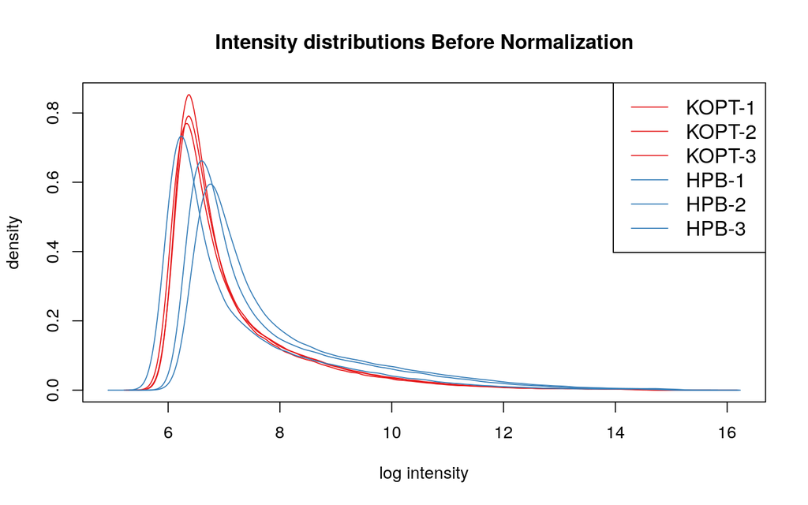

```r
#########################
# Intensity distributions
#########################

# Show intensity distributrions with hist function
H <- hist(rawdata_control, lty = rep(1, length(CELfiles_control )), col = mycols,
   main = "Intensity distributions Before Normalization", cex.labels = 3)
# Add legend in the top right corner
legend_names <- c("KOPT-1", "KOPT-2", "KOPT-3", "HPB-1", "HPB-2", "HPB-3")
legend("topright", rownames(pData(rawdata_control)),
       lty = rep(1, length(CELfiles_control )),
       col = mycols,
       cex = 1.2,
       legend = legend_names )
```

Observamos que entre microarrays del tipo celular KOPT-T1 la distribución es muy parecida, pero en el caso del tipo celular HPB-ALL existen diferencias en la distribución entre microarrays, aunque nada preocupante. También se observa que la distribución entre tipos celulares es diferente.

### 3.2.2 Boxplot

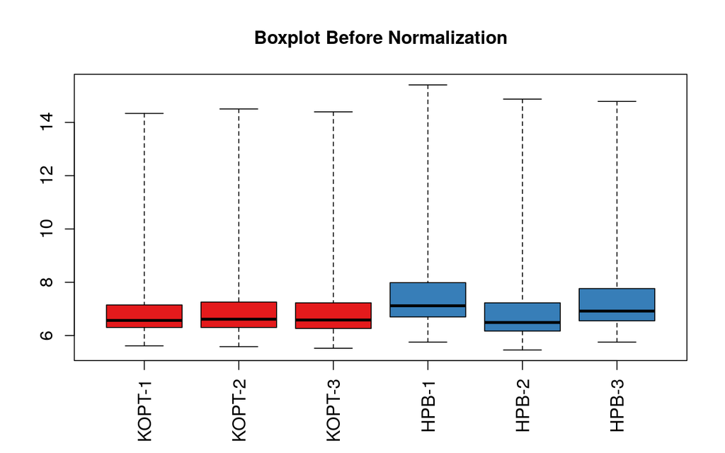

```r
# boxplot antes de normalizar
par(mfrow = c(1, 1)) ## two figures side by side

boxplot(rawdata_control,
        main="Boxplot Before Normalization",
        col = mycols,
        names = legend_names, # sampleNames(rawdata_control),
        las = 2,  # vertical labels
        cex.axis = 1.2, # size labels
        yaxt = "n") # do not show y labels
axis(2, cex.axis = 1.2) # plot y labels with higher size
```

Volvemos a observar los mismo que en el gráfico de las distribuciones de intensidades: existe mayor variación entre los microarrays pertenecientes al tipo celular HPB-ALL, que en el caso del tipo celular KOPT-K1. No obstante, no hay nada preocupante.

## 3.3 Normalización con RMA

```r
# Normalize with RMA
# generates object eset (class ExprSet),
#expresso function provides intensities in log scale
eset_control <- expresso(rawdata_control,
                 bg.correct = TRUE,
                 bgcorrect.method="rma", # corregir fondo
                 normalize = TRUE,
                 normalize.method="quantiles",
                 pmcorrect.method="pmonly", # los que machean perfectamente
                 summary.method="medianpolish", # resumeme por la mediana par aun mismo gen
                 verbose = TRUE,
)
```

```
## background correction: rma
## normalization: quantiles
## PM/MM correction : pmonly
## expression values: medianpolish
## background correcting...done.
## normalizing...done.
## 54675 ids to be processed
## |                    |
## |####################|
```

### 3.3.1 Distribución de la intensidad tras la normalización

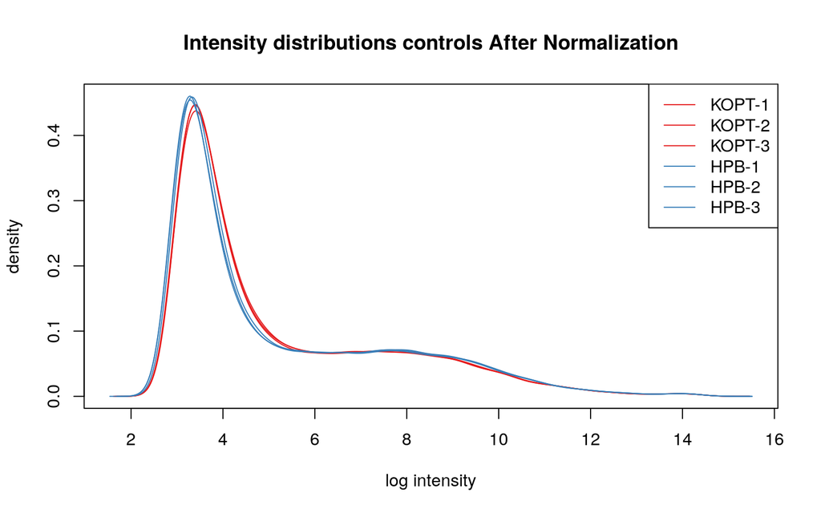

```r
# Intensity distributions after normalization

# Show intensity distributrions
exprseset_control <- as.data.frame(exprs(eset_control)) # cojo las intensidades normalizadas
dens_control <- apply(data.frame(exprseset_control), 2, density)

plot(NA, xlim=range(sapply(dens_control, "[", "x")),
     ylim=range(sapply(dens_control, "[", "y")),
     main = "Intensity distributions controls After Normalization",
     xlab = "log intensity", ylab = "density")
distribution_control <- mapply(lines, dens_control, col=c(rep(mycols[1], 3), rep(mycols[4], 3)), lwd = 1)
legend_names <- c("KOPT-1", "KOPT-2", "KOPT-3", "HPB-1", "HPB-2", "HPB-3")
# Add legend in the top right corner names(dens_control)
legend("topright", legend=legend_names, lty = rep(1, length(CELfiles_control)), col = mycols, cex = 1)
```

### 3.3.2 Boxplots tras la normalización

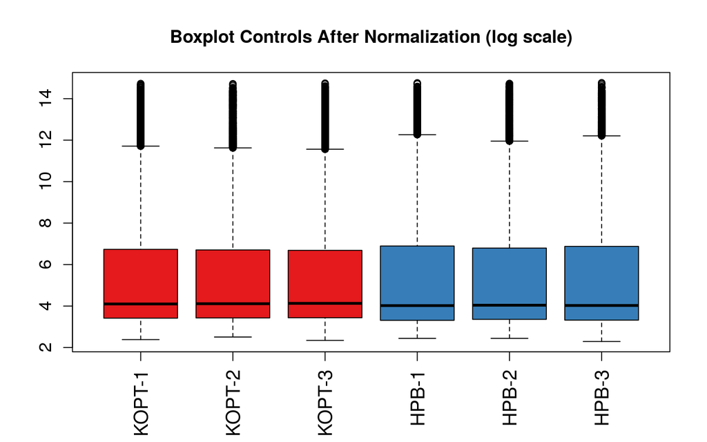

```r
# boxplot de todos los genes después de normalizar
boxplot(data.frame(exprseset_control),
        main="Boxplot Controls After Normalization (log scale)",
        col = mycols,
        names = legend_names, # sampleNames(rawdata_control),
        las = 2,  # vertical labels
        cex.axis = 1.3, # size labels
        yaxt = "n") # do not show y labels
axis(2, cex.axis = 1.2) # plot y labels with higher size
```

### 3.3.3 Scatter plot and MA-plot tras normalización

```r
# Note that the original eset object contains the log2-transformed gene intensities
exprseset_control <- as.data.frame(exprs(eset_control)) # retrieve log2 intensities
head(exprseset_control) # show log2 intensities
```

```
##           GSM455115.CEL GSM455116.CEL GSM455117.CEL GSM455118.CEL GSM455119.CEL
## 1007_s_at      7.806497      7.885510      7.961744      7.911682      8.044449
## 1053_at        9.125737      8.939494      9.024928      9.199080      9.050382
## 117_at         3.804166      3.633769      3.911939      3.655173      3.707292
## 121_at         7.767082      7.826770      7.729648      6.625446      7.041355
## 1255_g_at      3.447436      3.299026      3.295516      3.188791      3.053338
## 1294_at        7.743012      7.447743      7.262890      6.067091      6.463101
##           GSM455120.CEL
## 1007_s_at      7.882407
## 1053_at        9.056554
## 117_at         3.822320
## 121_at         6.624944
## 1255_g_at      3.112889
## 1294_at        6.441958
```

```r
# Normal intensity
intens_control = 2^exprseset_control # transform from log2 to normal intensity
head(intens_control)
```

```
##           GSM455115.CEL GSM455116.CEL GSM455117.CEL GSM455118.CEL GSM455119.CEL
## 1007_s_at     223.86690    236.469480     249.30083    240.798459    264.010079
## 1053_at       558.62512    490.971111     520.92343    587.758471    530.195992
## 117_at         13.96909     12.412910      15.05258     12.598438     13.061895
## 121_at        217.83353    227.034904     212.25395     98.731996    131.722236
## 1255_g_at      10.90892      9.842508       9.81859      9.118463      8.301303
## 1294_at       214.22924    174.579777     153.58463     67.046519     88.224117
##           GSM455120.CEL
## 1007_s_at     235.96134
## 1053_at       532.46902
## 117_at         14.14598
## 121_at         98.69768
## 1255_g_at       8.65113
## 1294_at        86.94062
```

Para realizar el scatter plot es necesario combinar las réplicas de cada línea celular. Se emplea la mediana en preferencia a la media, dado que la mediana es más robusta para situaciones con tamaño muestral pequeño (como en nuestro caso donde $n = 3$) [1].

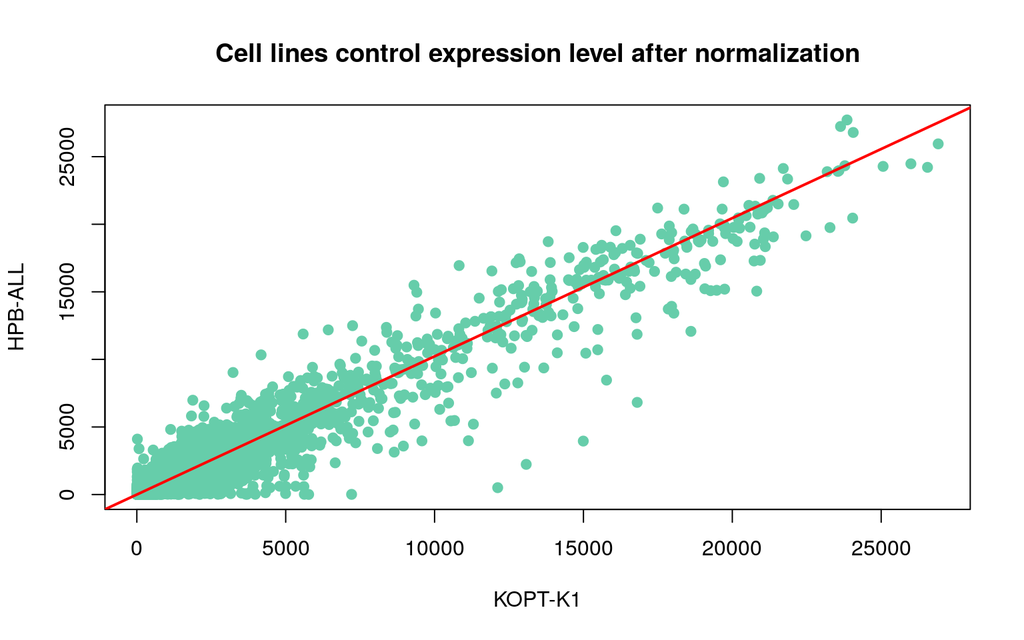

```r
# Create reference median array for each cell line to compare
# median intensity for KOPT-K1 control DMSO
intens_control_KOPT = apply(intens_control[, c(1, 2, 3)], 1, median)
# median intensity for HPB-ALL control DMSO
intens_control_HPB = apply(intens_control[, c(4, 5, 6)], 1, median)

plot(intens_control_KOPT, intens_control_HPB, cex = 1,
     pch = 19, col = "mediumaquamarine",
     xlab = "KOPT-K1",
     ylab = "HPB-ALL",
     main = "Cell lines control expression level after normalization")

abline(a = 0,
       b = (max(intens_control[, 4]) / max(intens_control[, 1])), col = "red",
       lwd = 2)
```

La gráfica de scatter-plot nos permite observar que la mayoría de los genes están localizados en la diagonal y no hay un patrón en la nube de puntos, así que la mayoría de los genes estudiados son expresados a niveles similares en ambos tipos de células. Sin embargo, hay algunos genes que están separados de la diagonal, siendo más expresados en uno de los dos tipos de células. Es interesante continuar con la expresión diferencial análisis basados en métodos estadísticos para comprobar si estas diferencias son significativo y debemos estudiar las líneas celulares por separado.

Otro tipo de gráfico utilizado es el gráfico de “ratio-versus-intensity” (gráfico MA). En esta gráfica, en el eje y se traza el ratio de intensidad (M) frente a la intensidad media (A).

Asumimos que la mayoría de los genes no verían ningún cambio en su expresión entre las líneas celulares KOPT-K1 y HPB-ALL, por lo que se situarán en $y=0$

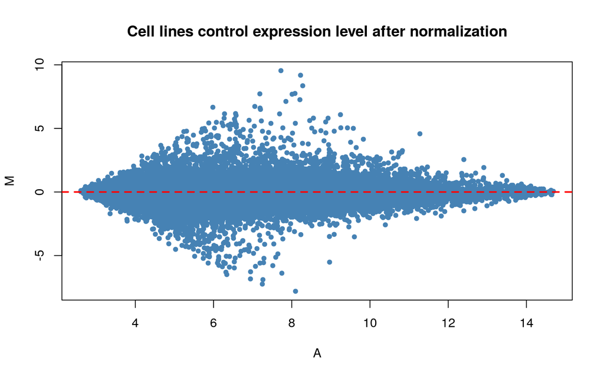

```r
A <- 1/2*log2(intens_control_KOPT*intens_control_HPB)
M <- log2(intens_control_KOPT/intens_control_HPB)
plot(A, M, cex = 0.75, pch = 19, col = "steelblue",
     main = "Cell lines control expression level after normalization" )

abline(h = 0, col = "red", lty = 2, lwd = 2)
```

Volvemos a ver que la mayoría de genes se sitúa en torno al valor central $y=0$, lo que indica que se expresan igual en ambos tipos celulares. No obstante, existen genes que se alejan de este valor central que deben ser estudiados.

Existen genes diferencialmente expresados en ambos tipos celulares. Ya tenemos indicios de que las líneas celulares son diferentes. Algunos de esos genes podrían afectar al estudio, como comprobaremos más adelante

### 3.3.4 Filtro del rango intercuartílico

```r
# boxplot de solo los genes normalizados con un ranog intercuartílico superior a 0.5 para que tengan variabilidad
esetIQR_control <- varFilter(eset_control, var.func=IQR, var.cutoff=0.5, filterByQuantile=TRUE)

## Comprobamos el filtro del rango intercuartílico
dim(exprs(eset_control))
```

```
## [1] 54675     6
```

```r
dim(exprs(esetIQR_control))
```

```
## [1] 27335     6
```

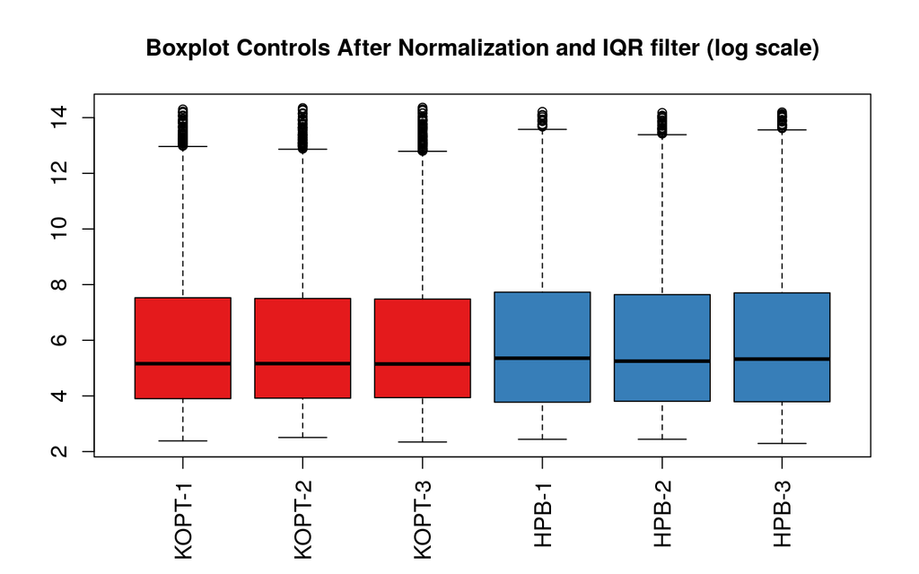

```r
# boxplot de solo los genes normalizados con un ranog intercuartílico superior a 0.5 para que tengan variabilidad
exprsesetIQR_control <- as.data.frame(exprs(esetIQR_control))

boxplot(data.frame(exprsesetIQR_control),
        main="Boxplot Controls After Normalization and IQR filter (log scale)",
        col = mycols[1:6],
        names = legend_names, # sampleNames(rawdata_control),
        las = 2,  # vertical labels
        cex.axis = 1.2, # size labels
        yaxt = "n") # do not show y labels
axis(2, cex.axis = 1.2) # plot y labels with higher size
```

### 3.3.5 PCA

La PCA es una herramienta que permite visualizar la distribución de las muestras en función de las variables (genes). La utilidad de la PCA es la capacidad de visualizar esta distribución en pocas dimensiones cuando se disponen de múltiples dimensiones. Es importante siempre indicar cuanta varianza es explicada por las componentes seleccionadas para la representación. Cuanto mayor sea esta mayor fiabilidad de la distribución de los datos.

```r
PCA_g <- prcomp(t(exprs(eset_control)))
summary(PCA_g)
```

```
## Importance of components:
##                            PC1      PC2      PC3      PC4     PC5       PC6
## Standard deviation     85.5972 18.99903 16.39949 14.71530 14.5936 2.635e-13
## Proportion of Variance  0.8737  0.04304  0.03207  0.02582  0.0254 0.000e+00
## Cumulative Proportion   0.8737  0.91671  0.94878  0.97460  1.0000 1.000e+00
```

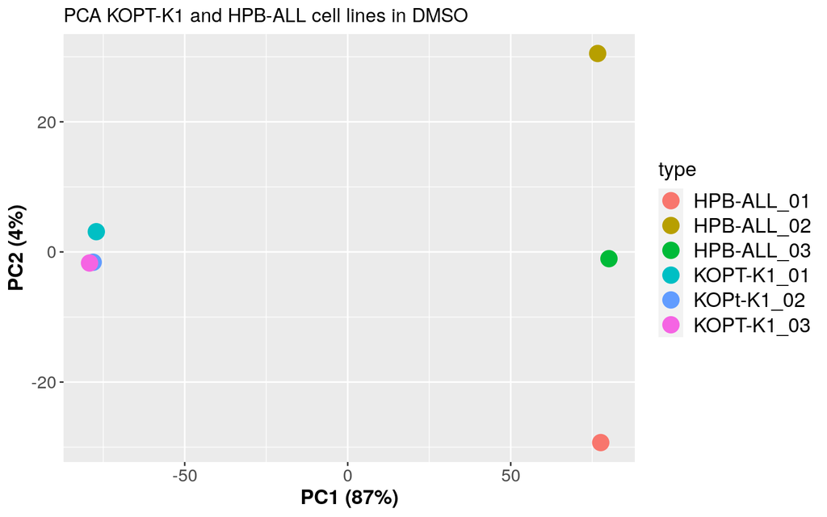

```r
rownames(PCA_g$x) <- c("KOPT-K1_01", "KOPt-K1_02", "KOPT-K1_03", "HPB-ALL_01", "HPB-ALL_02", "HPB-ALL_03")
pc_dat<- data.frame(type = rownames(PCA_g$x), PC1 = PCA_g$x[,1], PC2=PCA_g$x[,2])
library(ggplot2)
ggplot(pc_dat,aes(x=PC1, y=PC2, col=type)) + geom_point(size = 5) + theme(
  legend.title = element_text(color = "black", size = 14),
  legend.text = element_text(color = "black" , size = 14),
  axis.text=element_text(size=12),
  axis.title=element_text(size=14,face="bold")) + xlab("PC1 (87%)") + ylab("PC2 (4%)") +
  ggtitle("PCA KOPT-K1 and HPB-ALL cell lines in DMSO")
```

## 3.4 Expresión diferencial

### 3.4.1 Análisis estadístico

Generamos la matriz donde guardaremos el diseño experimental que empleará *makeContrast* para realizar la comparación de niveles de transcripción. A cada archivo .CEL le asigno un número en función del tratamiento y línea celular.

- KOPT-K1_DMSO $\rightarrow$ 1
- HPB-ALL_DMSO $\rightarrow$ 2

```r
# Generamos la matriz de diseño experimental
design_control <- model.matrix(~ 0+factor(c(1,1,1,2,2,2)))
rownames(design_control)<-sampleNames(rawdata_control)
colnames(design_control) <- c("KOPT_DMSO", "HPB_DMSO")
```

Realizamos el ajuste de cada grupo a una recta y realizamos el estudio de expresión diferencial empleando la función *makeContrast*

```r
## ajustamos cada nube de puntos correspondiente a cada grupo a una recta
fit_control <- lmFit(esetIQR_control, design_control)

## establecemos las comparaciones que queremos realizar
contrast.matrix_control <- makeContrasts(KOPT_DMSO - HPB_DMSO, levels=design_control)

## comparamos las regresiones lineales según el patrón de contraste pedido
fit2_control <- contrasts.fit(fit_control, contrast.matrix_control)

fit2_control<-eBayes(fit2_control)
```

```r
#Table with DEGs results number te cogerá todos los genes (filas) que tenia esetIQR
toptableIQR_control<-topTable(fit2_control, number=dim(exprs(esetIQR_control))[1],
                              adjust.method="BH", coef = 1,  sort.by="p")
# para poder ordenar por "p" necesito poner el coeficiente, es decir, que sepa que comparación debe coger
head(toptableIQR_control)
```

```
##                 logFC  AveExpr         t      P.Value    adj.P.Val        B
## 217143_s_at  9.181727 8.226860 105.68364 1.049698e-14 2.869351e-10 22.46369
## 213830_at    7.792512 8.059456  78.14391 1.408213e-13 9.775820e-10 20.96437
## 216191_s_at  9.419303 7.722709  77.36151 1.535467e-13 9.775820e-10 20.90699
## 218332_at   -7.836812 8.065131 -76.17011 1.754642e-13 9.775820e-10 20.81757
## 208892_s_at  7.701069 8.022880  76.00268 1.788151e-13 9.775820e-10 20.80481
## 202687_s_at  6.513351 7.208454  70.85198 3.268780e-13 1.489202e-09 20.38621
```

Ahora quiero quedarme solo con los genes que cumplan un FDR<0.05 (adjusted P-value)

```r
# Data frame with the values of the spot
Control.fdr.005.table<-subset(toptableIQR_control,
                              toptableIQR_control$adj.P.Val<=0.05)
dim(Control.fdr.005.table)
```

```
## [1] 20612     6
```

```r
summary(Control.fdr.005.table) ##  Check the maximum adj.P.val is < 0.05
```

```
##      logFC             AveExpr             t              P.Value
##  Min.   :-7.83681   Min.   : 2.718   Min.   :-76.170   Min.   :0.0000000
##  1st Qu.:-0.72872   1st Qu.: 4.293   1st Qu.: -6.254   1st Qu.:0.0000222
##  Median :-0.31681   Median : 6.091   Median : -2.676   Median :0.0006292
##  Mean   :-0.08468   Mean   : 6.352   Mean   : -0.731   Mean   :0.0048590
##  3rd Qu.: 0.50962   3rd Qu.: 8.092   3rd Qu.:  4.333   3rd Qu.:0.0057410
##  Max.   : 9.41930   Max.   :14.112   Max.   :105.684   Max.   :0.0376883
##    adj.P.Val               B
##  Min.   :0.0000000   Min.   :-5.52029
##  1st Qu.:0.0001177   1st Qu.:-3.58054
##  Median :0.0016688   Median :-1.21603
##  Mean   :0.0075332   Mean   :-0.05755
##  3rd Qu.:0.0101509   3rd Qu.: 2.42646
##  Max.   :0.0499810   Max.   :22.46369
```

Hemos pasado de 54675 genes iniciales a 27335 tras el filtro IR y, finalmente, a 20612 genes tras el filtro de FDR.

### 3.4.2 Incorporación de los nombres de los genes

Queremos incorporar anotaciones a *Control.fdr.005.table*

```r
library("hgu133plus2.db")
```

```r
# Recuperamos los nombres de las sondas de los diferentes spots del microarray
Control_probenames.fdr.005<-as.character(rownames(Control.fdr.005.table))
head(Control_probenames.fdr.005)
```

```
## [1] "217143_s_at" "213830_at"   "216191_s_at" "218332_at"   "208892_s_at"
## [6] "202687_s_at"
```

```r
# Recuperamos la lista de genes asociados a las diferentes sondas del microarray
Control_list.GeneSymbol.fdr.005<-mget(Control_probenames.fdr.005, hgu133plus2SYMBOL)
head(Control_list.GeneSymbol.fdr.005)
```

```
## $`217143_s_at`
## [1] "YME1L1"
##
## $`213830_at`
## [1] "YME1L1"
##
## $`216191_s_at`
## [1] NA
##
## $`218332_at`
## [1] "BEX1"
##
## $`208892_s_at`
## [1] "DUSP6"
##
## $`202687_s_at`
## [1] "TNFSF10"
```

```r
# ahora mostrmos solo los nombres de los genes
Control_char.GeneSymbol.fdr.005<- as.character(Control_list.GeneSymbol.fdr.005)
head(Control_char.GeneSymbol.fdr.005)
```

```
## [1] "YME1L1"  "YME1L1"  "NA"      "BEX1"    "DUSP6"   "TNFSF10"
```

```r
# Añadimos al data frame la columna con los nombres de los genes
Control_toptable.annotated<-cbind(Control.fdr.005.table, Control_char.GeneSymbol.fdr.005)
head(Control_toptable.annotated)
```

```
##                 logFC  AveExpr         t      P.Value    adj.P.Val        B
## 217143_s_at  9.181727 8.226860 105.68364 1.049698e-14 2.869351e-10 22.46369
## 213830_at    7.792512 8.059456  78.14391 1.408213e-13 9.775820e-10 20.96437
## 216191_s_at  9.419303 7.722709  77.36151 1.535467e-13 9.775820e-10 20.90699
## 218332_at   -7.836812 8.065131 -76.17011 1.754642e-13 9.775820e-10 20.81757
## 208892_s_at  7.701069 8.022880  76.00268 1.788151e-13 9.775820e-10 20.80481
## 202687_s_at  6.513351 7.208454  70.85198 3.268780e-13 1.489202e-09 20.38621
##             Control_char.GeneSymbol.fdr.005
## 217143_s_at                          YME1L1
## 213830_at                            YME1L1
## 216191_s_at                              NA
## 218332_at                              BEX1
## 208892_s_at                           DUSP6
## 202687_s_at                         TNFSF10
```

Reordenamos las columnas colocando la nueva columna con los nombres de los genes en primer lugar

```r
# Change name column added
colnames(Control_toptable.annotated)[length(colnames(Control_toptable.annotated))] <- "Gene_Name"

# Get column names
colnames(Control_toptable.annotated)
```

```
## [1] "logFC"     "AveExpr"   "t"         "P.Value"   "adj.P.Val" "B"
## [7] "Gene_Name"
```

```r
# Reordering colnumns by positions. We want "Gene_names" as the second column

Control_toptable.annotated<- Control_toptable.annotated[, c("Gene_Name", "logFC", "AveExpr", "t", "P.Value", "adj.P.Val", "B")]
head(Control_toptable.annotated)
```

```
##             Gene_Name     logFC  AveExpr         t      P.Value    adj.P.Val
## 217143_s_at    YME1L1  9.181727 8.226860 105.68364 1.049698e-14 2.869351e-10
## 213830_at      YME1L1  7.792512 8.059456  78.14391 1.408213e-13 9.775820e-10
## 216191_s_at        NA  9.419303 7.722709  77.36151 1.535467e-13 9.775820e-10
## 218332_at        BEX1 -7.836812 8.065131 -76.17011 1.754642e-13 9.775820e-10
## 208892_s_at     DUSP6  7.701069 8.022880  76.00268 1.788151e-13 9.775820e-10
## 202687_s_at   TNFSF10  6.513351 7.208454  70.85198 3.268780e-13 1.489202e-09
##                    B
## 217143_s_at 22.46369
## 213830_at   20.96437
## 216191_s_at 20.90699
## 218332_at   20.81757
## 208892_s_at 20.80481
## 202687_s_at 20.38621
```

### 3.4.3 Presencia de los genes *HES1, MYC, DTX1* en DEGs entre líneas celulares

Aquí no puedo comprobar nada en específico del paper porque el paper no estudia este escenario. Pero sí ver si los genes que mostraban encontrarse sub-regulados en el tratamiento con SAHM1: *HES1, MYC, DTX1* se encuentran también diferencialmente expresados entre ambos tipos celulares. Si estos genes están entre los genes diferencialmente expresados entre los dos tipos celulares, clarísimamente tenemos que estudiar los dos tipos celulares por separado, porque su estudio en conjunto enmascararía el resultado encontrado en el paper. Si las líneas celulares que vamos a usar de control ya tienen diferentes esos genes, cuando hagamos la comparación con el tratamiento con SAHM1 nos va a costar mucho más encontrar diferencias, porque las propias diferencias entre los tipos celulares lo estás usando para normalizar y eso nos va a hacer perder señal.

Pero antes, veamos si están estos genes *HES1, MYC, DTX1* entre los genes diferencialmente expresados:

```r
# Busco si los genes del artículo se encuentran entre los genes diferencialmente expresados
"HES1" %in% unique(Control_toptable.annotated$Gene_Name)
```

```
## [1] TRUE
```

```r
"MYC" %in% unique(Control_toptable.annotated$Gene_Name)
```

```
## [1] TRUE
```

```r
"DTX1" %in% unique(Control_toptable.annotated$Gene_Name)
```

```
## [1] TRUE
```

```r
"HES4" %in% unique(Control_toptable.annotated$Gene_Name)
```

```
## [1] TRUE
```

Lo ideal sería estudiar las líneas celulares por separado. Porque si las agrupamos en un solo grupo control, cuando comparemos con el tratamiento con ASHM1, si nos salen esos genes expresados diferencialmente no podremos saber si esa expresión diferencial se debe al tratamiento con ASMH1 o al tipo celular.

### 3.4.4 Volcano plot

Un gráfico volcano-plot muestra el logFC en el eje horizontal, y los valores $p$ en el eje vertical, para cada gen. Los umbrales para ambos ejes pueden ser aplicados simultáneamente.

Realizo en análisis estadístico con todos los spots del microarray en vez de realizar como paso previo al filtrado por IQR para poder visualizar la totalidad de los spots del microarray.

```r
## ajustamos cada nube de puntos correspondiente a cada grupo a una recta
fit_control_completo <- lmFit(eset_control, design_control)

## establecemos las comparaciones que queremos realizar
## Tenemos que dividir entre 2 para que tengan todos el mismo peso. Las dos últimas no tienen ningún sentido
contrast.matrix_control_completo <- makeContrasts(KOPT_DMSO - HPB_DMSO, levels=design_control)

## comparamos las regresiones lineales según el patrón de contraste pedido
fit2_control_completo <- contrasts.fit(fit_control_completo, contrast.matrix_control_completo)

fit2_control_completo<-eBayes(fit2_control_completo)

#Table with DEGs results number te cogerá todos los genes (filas) que tenia esetIQR

toptable_control_completo<-topTable(fit2_control_completo, number=dim(exprs(eset_control))[1],
                              adjust.method="BH", coef = 1,  sort.by="p")
# length(rownames(toptable_control_completo)) 54675
```

Añadimos los nombres de los genes a todos los spots del microarray

```r
# Using the aternatively method
# if you wanted to extract only one column of data you could instead use themapIds method
library("hgu133plus2.db")
array_probenames <- as.character(rownames(toptable_control_completo))
array_list.GeneSymbol <- as.list(mapIds(hgu133plus2.db, keys=array_probenames, column="SYMBOL", keytype = "PROBEID"))
# Extraigo los nombres de los genes
array_char.GeneSymbol <- as.character(array_list.GeneSymbol)

# Añadimos al data frame la columna con los nombres de los genes
array_toptable.annotated<-cbind(toptable_control_completo, array_char.GeneSymbol)

# Change name column added
colnames(array_toptable.annotated)[length(colnames(array_toptable.annotated))] <- "GeneSymbol"

head(array_toptable.annotated)
```

[output not shown]

Ahora sí, procedemos a realizar el vulcano plot. Extraemos primero las columnas de interés para facilitar el manejo de los datos. Seleccionamos los genes que muestran un P valor ajustado menor que 0.05 para ser coloreados y se plotean en función de su P valor.

En azul se encuentran los genes que se expresan con un log Fold Change superior a 1 en valor absoluto con un q-value < 0.05 (P valor ajustado). En naranja los genes expresados con un Fold Change inferior a 1 en valor absoluto, pero con un q-value < 0.05.

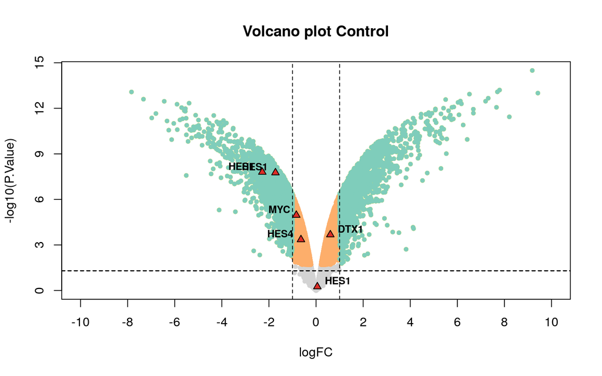

```r
# Extraemos columnas de interés
vulcano_data <- subset(array_toptable.annotated, select = c("GeneSymbol", "logFC", "P.Value", "adj.P.Val"))

# Cojo el mayor y menor valor de nuestros datos y le doy un margen
min_value <- min(vulcano_data$logFC)-0.5
max_value <- max(vulcano_data$logFC)+0.5
# mis limites se generaran en función del valor más grande en valor absoluto
myxlim <- round(max( -min_value, max_value))

# Make a basic volcano plot
with(vulcano_data, plot(logFC, -log10(P.Value), pch=20,
                        main="Volcano plot Control",
                        col = "lightgray",
                        xlim=c(-myxlim, myxlim),
                        xaxp = c(-10, 10, 10),
                        yaxp = c(0, 15, 5)))

# Add colored points: red if adj.P.Val<0.05, orange of log2FC>1.5, green if both)
with(subset(vulcano_data, adj.P.Val<.05), points(logFC, -log10(P.Value), pch=20, col="#fdae6b",))
with(subset(vulcano_data, abs(logFC)>1), points(logFC, -log10(P.Value), pch=20, col="yellow"))
with(subset(vulcano_data, adj.P.Val<.05 & abs(logFC)>1), points(logFC, -log10(P.Value), pch=20, col="#7fcdbb"))

# which(genesymbols %in% "MYC") # 5191
# which(genesymbols %in% "DTX1") # 9643
# which(genesymbols %in% "HES1") # 812, 834, 45900
genesymbols <- as.vector(vulcano_data$GeneSymbol)
# Colour gene selected
with(vulcano_data[c(which(genesymbols %in% "HES1"),
                    which(genesymbols %in% "MYC"),
                    which(genesymbols %in% "DTX1"),
                    which(genesymbols %in% "HES4")), ],
     points(logFC, -log10(P.Value), pch = 24, bg = "#de2d26", col = "black"))
# Creamos un vector con tantos elementos vacios como spots
mylabels <- rep("", 54675)
# Saco la lista de nombres de genes

# Añadimos la etiqueta deseada en la posición deseada
mylabels[which(genesymbols %in% "MYC")] <- "MYC"
mylabels[which(genesymbols %in% "DTX1")] <- "DTX1"
mylabels[which(genesymbols %in% "HES1")] <- "HES1"
mylabels[which(genesymbols %in% "HES4")] <- "HES4"


# Label points with the textxy function from the calibrate plot
library(calibrate)
with(subset(vulcano_data, adj.P.Val & abs(logFC)), textxy(logFC, -log10(P.Value), labs = mylabels, cex=0.8, font = 2))

# Add limit dotted lines
abline (v = 1, lty = 2 )
abline (v = -1, lty = 2)
# obtengo el P valor asociado al adj.P.valor < 0.05 empleado como corte
abline (h = -log10(tail(vulcano_data[ vulcano_data$adj.P.Val < 0.05 , ]$adj.P.Val)), lty = 2)
```

```r
# Numero de genes sobre-expresados con p-valor ajustado < 0.05 y logFC > 1
dim(vulcano_data[ vulcano_data$adj.P.Val < 0.05 & vulcano_data$logFC > 1 , ])
```

```
## [1] 1865    4
```

```r
# Numero de genes sub-expresados con p-valor ajustado < 0.05 y logFC < 1
dim(vulcano_data[ vulcano_data$adj.P.Val < 0.05 & vulcano_data$logFC < -1 , ])
```

```
## [1] 3016    4
```

El gen HES1 presenta tres sondas dentro del microarray, y una de ellas se observa que no se encuentra diferencialmente expresada. Esta sonda podría corresponder a una de las isoformas del gen HES1, mostrándose así que las distintas isoformas de un gen presentan distintos niveles de expresión.

## 3.5 Clusterización

Creo el archivo **.csv** que emplearé para estudiar en Morpheus la clusterización jerarquizada y no jerarquizada.

```r
# genes diferencialmente expresados
diff_genes <- unique(rownames(vulcano_data[ vulcano_data$adj.P.Val < 0.05 , ] ))

# length(diff_genes) # 20828
exprseset_control_diff <- exprseset_control[rownames(exprseset_control) %in% diff_genes[0:35], ]

# Cambiamos los nombres de las muestras
colnames(exprseset_control_diff) <- c("KOPT-K1_01", "KOPT-K1_02", "KOPT-K1_03",
                                                "HPB-ALL_01", "HPB-ALL_02", "HPB-ALL_03")

# Nombre de los spots
spots_control_diff <- rownames(exprseset_control_diff)

spots_control_diff_list.GeneSymbol <- as.list(mapIds(hgu133plus2.db, keys=spots_control_diff, column="SYMBOL", keytype = "PROBEID"))
spots_control_diff_char.GeneSymbol <- as.character(spots_control_diff_list.GeneSymbol)

# Añadimos al data frame la columna con los nombres de los genes
exprseset_control_diff.annotated<-cbind(exprseset_control_diff, spots_control_diff_char.GeneSymbol)

# Change name column added
colnames(exprseset_control_diff.annotated)[length(colnames(exprseset_control_diff.annotated))] <- "Description"


# Reordering colnumns by positions. We want "Gene_names" as the second column

exprseset_control_diff.annotated <-exprseset_control_diff.annotated[, c("Description", "KOPT-K1_01",
                                                                        "KOPT-K1_02", "KOPT-K1_03",
                                                                        "HPB-ALL_01", "HPB-ALL_02",
                                                                        "HPB-ALL_03")]
head(exprseset_control_diff.annotated)
```

```
##              Description KOPT-K1_01 KOPT-K1_02 KOPT-K1_03 HPB-ALL_01 HPB-ALL_02
## 1552316_a_at      GIMAP1  11.945017  11.905885  11.985329   6.952920   6.781019
## 201105_at         LGALS1   9.586760   9.609799   9.561716   3.663890   3.443361
## 201669_s_at       MARCKS   3.065019   2.950855   3.225982   8.653011   8.659325
## 201722_s_at       GALNT1   3.084618   3.090112   3.269802   9.676009   9.517618
## 202554_s_at        GSTM3   3.423736   3.489462   3.430523   8.903074   8.801179
## 202687_s_at      TNFSF10  10.403072  10.446713  10.545603   3.988092   3.913979
##              HPB-ALL_03
## 1552316_a_at   6.902563
## 201105_at      3.565737
## 201669_s_at    8.708282
## 201722_s_at    9.587416
## 202554_s_at    8.811082
## 202687_s_at    3.953263
```

```r
write.csv(exprseset_control_diff.annotated, file = "Control_diff_top_35.csv")
```

# 4 Lineas celulares estudiadas por separado

## 4.1 Línea celular KOPT-K1

Los ficheros control son:

- KOPT-K1_DMSO $\rightarrow$ “GSM455115.CEL”, “GSM455116.CEL”, “GSM455117.CEL”
- KOPT-K1_SAHM1 $\rightarrow$ “GSM455121.CEL”, “GSM455122.CEL”, “GSM455123.CEL”

### 4.1.1 Cargamos los ficheros .CEL y extraemos el raw data

```r
# Read .CEL files
# data <- ReadAffy(filenames=targets$FileName)
CELfiles_KOPT <- c("GSM455115.CEL", "GSM455116.CEL", "GSM455117.CEL", "GSM455121.CEL", "GSM455122.CEL", "GSM455123.CEL")

rawdata_KOPT <- ReadAffy(filenames = CELfiles_KOPT)
rawdata_KOPT
```

```
## AffyBatch object
## size of arrays=1164x1164 features (20 kb)
## cdf=HG-U133_Plus_2 (54675 affyids)
## number of samples=6
## number of genes=54675
## annotation=hgu133plus2
## notes=
```

## 4.2 Análisis exploratorio de la calidad de los datos iniciales

### 4.2.1 Distribución de las intensidades antes de normalizar

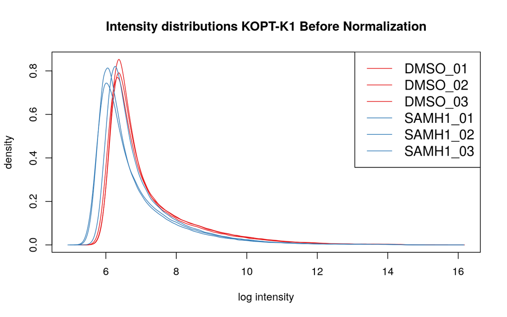

```r
#########################
# Intensity distributions
#########################

# Show intensity distributrions with hist function
hist(rawdata_KOPT, lty = rep(1, length(CELfiles_KOPT)), col = mycols,
   main = "Intensity distributions KOPT-K1 Before Normalization" )

# Add legend in the top right corner
legend("topright",  c("DMSO_01", "DMSO_02", "DMSO_03", "SAMH1_01", "SAMH1_02", "SAMH1_03"),
       lty = rep(1, length(CELfiles_KOPT)),
       col = mycols,
       cex = 1.3)
```

### 4.2.2 Boxplot antes de normalizar

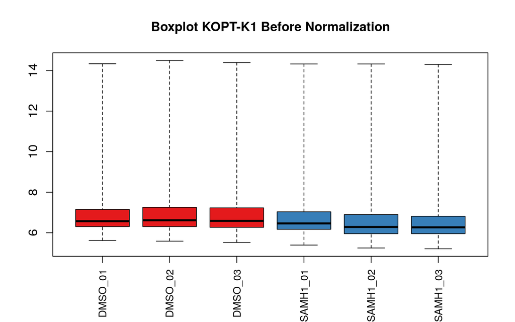

```r
#############################
# boxplot antes de normalizar
#############################

boxplot(rawdata_KOPT,
        main="Boxplot KOPT-K1 Before Normalization",
        col = mycols,
        names = c("DMSO_01", "DMSO_02", "DMSO_03", "SAMH1_01", "SAMH1_02", "SAMH1_03"), # sampleNames(rawdata_KOPT),
        las = 2,  # vertical labels
        cex.axis = 0.97, # size labels
        yaxt = "n") # do not show y labels
axis(2, cex.axis = 1.2) # plot y labels with higher size
```

Volvemos a observar la necesidad de normalizar los datos.

## 4.3 Normalización con RMA

```r
#4. Normalize with RMA
#generates object eset (class ExprSet),
#expresso function provides intensities in log scale
eset_KOPT <- expresso(rawdata_KOPT,
                 bg.correct = TRUE,
                 bgcorrect.method="rma", # corregir fondo
                 normalize = TRUE,
                 normalize.method="quantiles",
                 pmcorrect.method="pmonly", # los que machean perfectamente
                 summary.method="medianpolish", # resumeme por la mediana par aun mismo gen
                 verbose = TRUE,
)
```

```
## background correction: rma
## normalization: quantiles
## PM/MM correction : pmonly
## expression values: medianpolish
## background correcting...done.
## normalizing...done.
## 54675 ids to be processed
## |                    |
## |####################|
```

### 4.3.1 Distribución de la intensidad tras la normalización

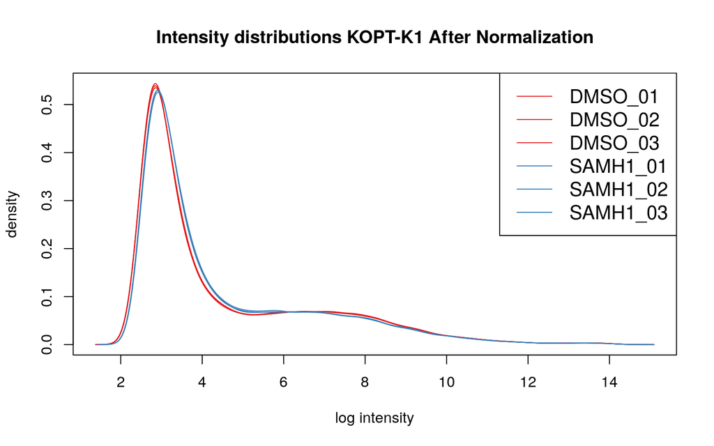

```r
#########################
# Intensity distributions
#########################

# Show intensity distributrions
exprseset_KOPT <- as.data.frame(exprs(eset_KOPT)) # cojo las intensidades normalizadas
dens_KOPT <- apply(data.frame(exprseset_KOPT), 2, density)

plot(NA, xlim=range(sapply(dens_KOPT, "[", "x")), ylim=range(sapply(dens_KOPT, "[", "y")),
     main = "Intensity distributions KOPT-K1 After Normalization",
     xlab = "log intensity", ylab = "density")
distribution_KOPT <- mapply(lines, dens_KOPT,
                            col=c(rep(mycols[1], 3), rep(mycols[4], 3)), lwd = 1)

# Add legend in the top right corner
legend("topright", legend= c("DMSO_01", "DMSO_02", "DMSO_03", "SAMH1_01", "SAMH1_02", "SAMH1_03")
         , lty = rep(1, length(CELfiles_KOPT)), col = mycols, cex = 1.3)
```

### 4.3.2 Boxplots tras la normalización

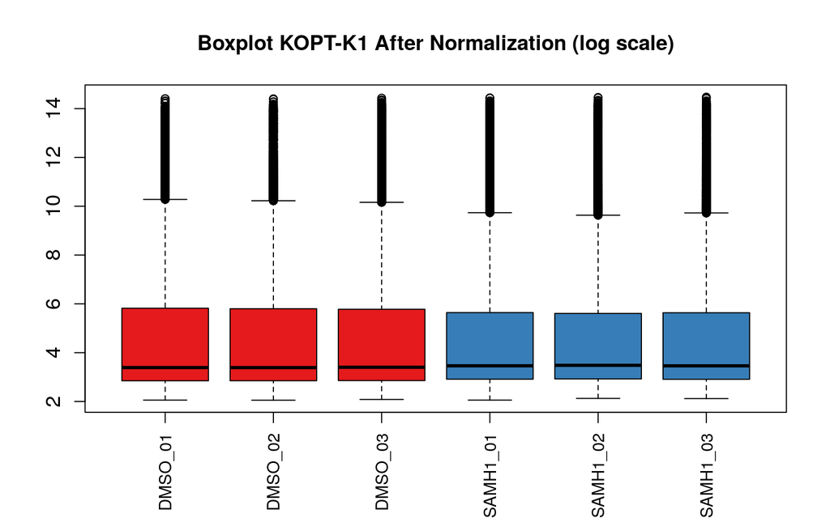

```r
# boxplot de todos los genes después de normalizar
boxplot(data.frame(exprseset_KOPT),
        main="Boxplot KOPT-K1 After Normalization (log scale)",
        col = mycols,
        names =c("DMSO_01", "DMSO_02", "DMSO_03", "SAMH1_01", "SAMH1_02", "SAMH1_03"), # sampleNames(rawdata_KOPT),
        las = 2,  # vertical labels
        cex.axis = 0.97, # size labels
        yaxt = "n") # do not show y labels
axis(2, cex.axis = 1.2) # plot y labels with higher size
```

### 4.3.3 Scatter plot tras la normalización

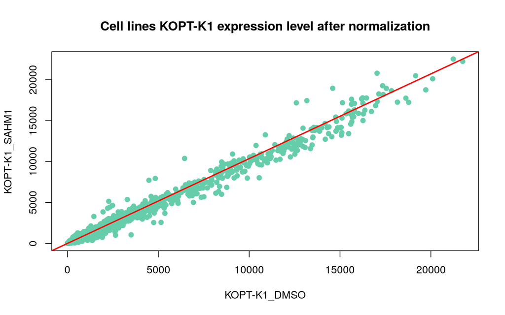

```r
# Note that the original eset object contains the log2-transformed gene intensities
intens_KOPT = 2^exprseset_KOPT # transform from log2 to normal intensity

# Create reference median array for each cell line to compare
# median intensity for KOPT-K1 control DMSO
intens_KOPT_DMSO = apply(intens_KOPT[, c(1, 2, 3)], 1, median)
# median intensity for HPB-ALL control DMSO
intens_KOPT_SAHM1 = apply(intens_KOPT[, c(4, 5, 6)], 1, median)

plot(intens_KOPT_DMSO, intens_KOPT_SAHM1, cex = 1,
     pch = 19, col = "mediumaquamarine",
     xlab = "KOPT-K1_DMSO",
     ylab = "KOPT-K1_SAHM1",
     main = "Cell lines KOPT-K1 expression level after normalization")

abline(a = 0,
       b = (max(intens_KOPT_SAHM1) / max(intens_KOPT_DMSO)), col = "red",
       lwd = 2)
```

### 4.3.4 MA-plot tras la normalización

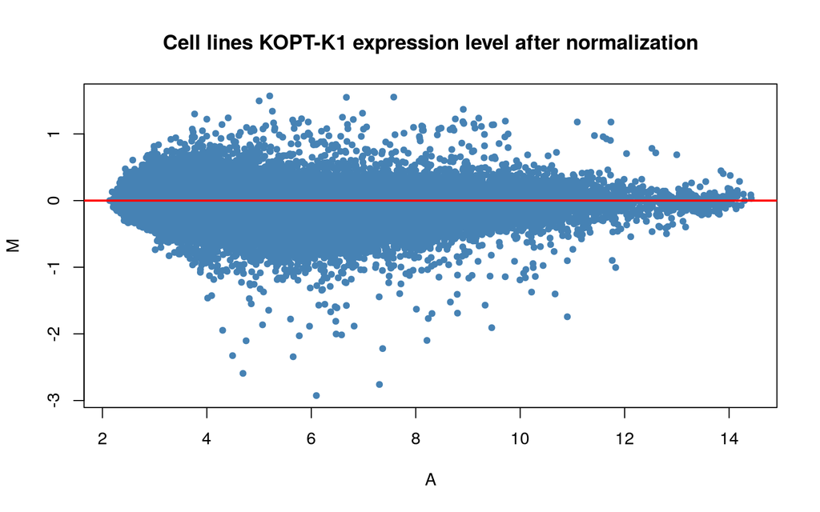

```r
A <- 1/2*log2(intens_KOPT_SAHM1*intens_KOPT_DMSO)
M <- log2(intens_KOPT_SAHM1/intens_KOPT_DMSO)
plot(A, M, cex = 0.75, pch = 19, col = "steelblue",
     main = "Cell lines KOPT-K1 expression level after normalization")

abline(h = 0, col = "red", lty = 1, lwd = 2)
```

Vemos que hay muchos genes subregulados en el tratamiento con SAHM1 con respecto al tratamiento control con DMSO.

### 4.3.5 PCA

```r
PCA_g <- prcomp(t(exprs(eset_KOPT)))
rownames(PCA_g$x) <- c("DMSO_01", "DMSO_02", "DMSO_03", "SAMH1_01", "SAMH1_02", "SAMH1_03")
summary(PCA_g)
```

```
## Importance of components:
##                            PC1     PC2     PC3     PC4      PC5       PC6
## Standard deviation     30.0303 14.7327 13.8842 13.0588 11.59583 1.364e-13
## Proportion of Variance  0.5578  0.1343  0.1192  0.1055  0.08317 0.000e+00
## Cumulative Proportion   0.5578  0.6921  0.8113  0.9168  1.00000 1.000e+00
```

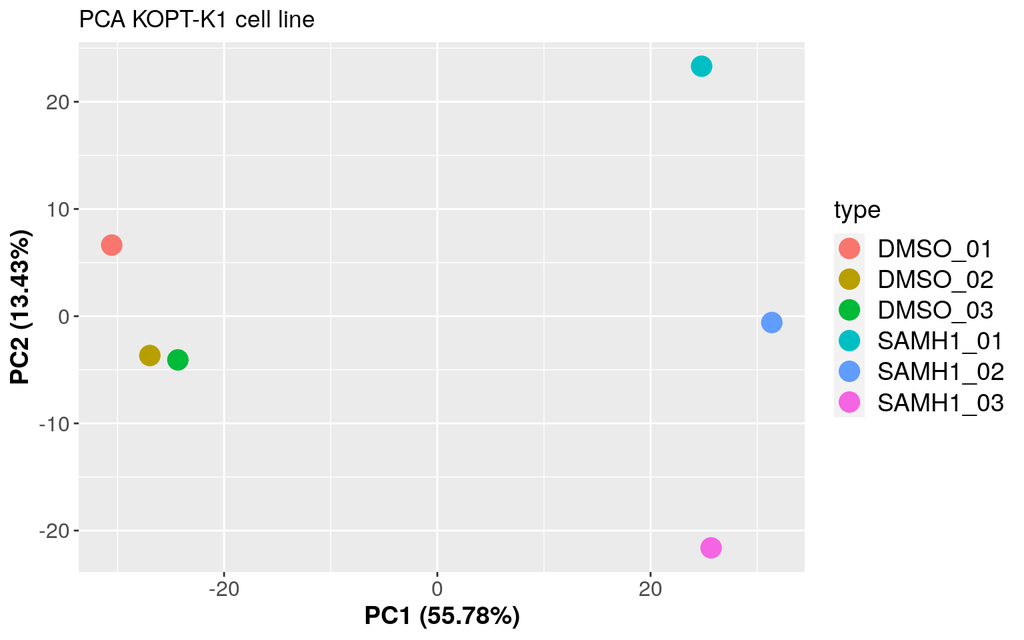

```r
pc_dat<- data.frame(type = rownames(PCA_g$x), PC1 = PCA_g$x[,1], PC2=PCA_g$x[,2])
library(ggplot2)
ggplot(pc_dat,aes(x=PC1, y=PC2, col=type)) + geom_point(size = 5) + theme(
  legend.title = element_text(color = "black", size = 14),
  legend.text = element_text(color = "black" , size = 14),
  axis.text=element_text(size=12),
  axis.title=element_text(size=14,face="bold")) + xlab("PC1 (55.78%)") + ylab("PC2 (13.43%)") +
  ggtitle("PCA KOPT-K1 cell line")
```

### 4.3.6 Filtro del rango intercuartílico

```r
# boxplot de solo los genes normalizados con un ranog intercuartílico superior a 0.5 para que tengan variabilidad
esetIQR_KOPT <- varFilter(eset_KOPT, var.func=IQR, var.cutoff=0.5, filterByQuantile=TRUE)

## Comprobamos el filtro del rango intercuartílico
dim(exprs(eset_KOPT))
```

```
## [1] 54675     6
```

```r
dim(exprs(esetIQR_KOPT))
```

```
## [1] 27337     6
```

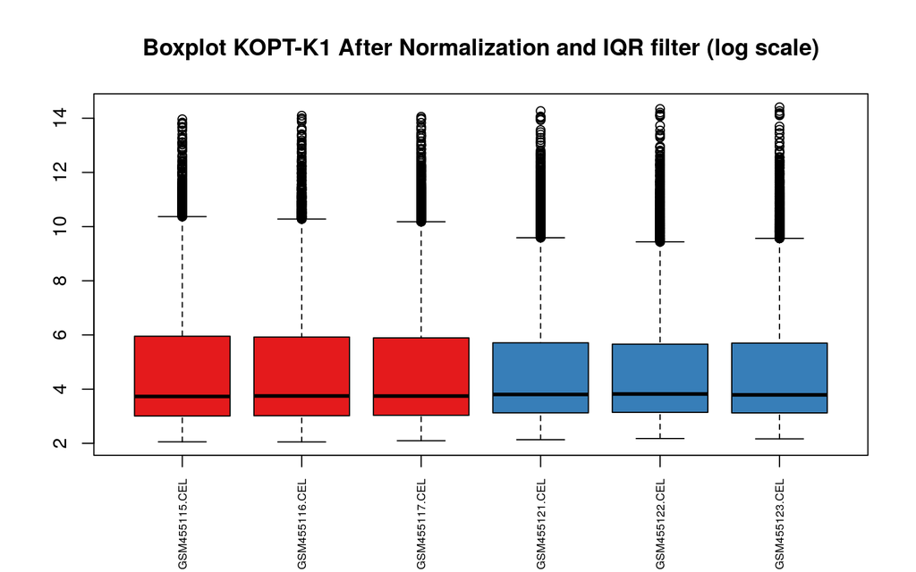

```r
# boxplot de solo los genes normalizados con un ranog intercuartílico superior a 0.5 para que tengan variabilidad
exprsesetIQR_KOPT <- as.data.frame(exprs(esetIQR_KOPT))

boxplot(data.frame(exprsesetIQR_KOPT),
        main="Boxplot KOPT-K1 After Normalization and IQR filter (log scale)",
        col = mycols,
        names = sampleNames(rawdata_KOPT),
        las = 2,  # vertical labels
        cex.axis = 0.6, # size labels
        yaxt = "n") # do not show y labels
axis(2, cex.axis = 1) # plot y labels with higher size
```

## 4.4 Expresión diferencial

### 4.4.1 Análisis estadístico

Generamos la matriz donde guardaremos el diseño experimental que empleará *makeContrast* para realizar la comparación de niveles de transcripción. A cada archivo .CEL le asigno un número en función del tratamiento y línea celular.

- KOPT-K1_DMSO $\rightarrow$ 1
- KOPT-K1_SAHM1 $\rightarrow$ 2

```r
# Generamos la matriz de diseño experimental
design_KOPT <- model.matrix(~ 0+factor(c(1,1,1,2,2,2)))
rownames(design_KOPT)<-sampleNames(rawdata_KOPT)
colnames(design_KOPT) <- c("KOPT_DMSO", "KOPT_SAHM1")

# Mostramos la matriz de diseño experimental
design_KOPT
```

```
##               KOPT_DMSO KOPT_SAHM1
## GSM455115.CEL         1          0
## GSM455116.CEL         1          0
## GSM455117.CEL         1          0
## GSM455121.CEL         0          1
## GSM455122.CEL         0          1
## GSM455123.CEL         0          1
## attr(,"assign")
## [1] 1 1
## attr(,"contrasts")
## attr(,"contrasts")$`factor(c(1, 1, 1, 2, 2, 2))`
## [1] "contr.treatment"
```

Realizamos el ajuste de cada grupo a una recta y realizamos el estudio de expresión diferencial empleando la función *makeContrast*

```r
## ajustamos cada nube de puntos correspondiente a cada grupo a una recta
fit_KOPT <- lmFit(esetIQR_KOPT, design_KOPT)

## establecemos las comparaciones que queremos realizar
## Tenemos que dividir entre 2 para que tengan todos el mismo peso. Las dos últimas no tienen ningún sentido
contrast.matrix_KOPT <- makeContrasts(KOPT_SAHM1 - KOPT_DMSO, levels=design_KOPT)

## comparamos las regresiones lineales según el patrón de contraste pedido
fit2_KOPT <- contrasts.fit(fit_KOPT, contrast.matrix_KOPT)

fit2_KOPT <- eBayes(fit2_KOPT)
```

```r
#Table with DEGs results number te cogerá todos los genes (filas) que tenia esetIQR

toptableIQR_KOPT<-topTable(fit2_KOPT, number=dim(exprs(esetIQR_KOPT))[1],
                              adjust.method="BH", coef = 1,  sort.by="p")
# para poder ordenar por "p" necesito poner el coeficiente, es decir, que sepa que comparación debe coger

head(toptableIQR_KOPT)
```

```
##                 logFC  AveExpr         t      P.Value    adj.P.Val        B
## 209921_at   -2.916468 6.070424 -22.79992 1.310423e-15 2.066610e-11 24.65260
## 209369_at   -2.661459 4.634765 -22.62865 1.511951e-15 2.066610e-11 24.53851
## 205047_s_at -2.757747 7.319915 -21.81169 3.034026e-15 2.764706e-11 23.97748
## 225285_at   -2.072317 8.217087 -19.05625 3.848602e-14 2.630231e-10 21.85800
## 226517_at   -2.216157 7.349580 -18.73189 5.303756e-14 2.899776e-10 21.58284
## 220892_s_at -1.938100 9.448362 -18.19936 9.078716e-14 4.136414e-10 21.11814
```

```r
dim((toptableIQR_KOPT))
```

```
## [1] 27337     6
```

Ahora quiero quedarme solo con los genes que cumplan un FDR<0.05 (adjusted P-value)

```r
# Data frame with the values of the spot
KOPT.fdr.005.table<-subset(toptableIQR_KOPT,
                              toptableIQR_KOPT$adj.P.Val<=0.05)
dim(KOPT.fdr.005.table)
```

```
## [1] 7765    6
```

```r
summary(KOPT.fdr.005.table) ##  Check the maximum adj.P.val is < 0.05
```

```
##      logFC            AveExpr             t              P.Value
##  Min.   :-2.9165   Min.   : 2.423   Min.   :-22.800   Min.   :0.0000000
##  1st Qu.:-0.4710   1st Qu.: 3.904   1st Qu.: -4.003   1st Qu.:0.0002769
##  Median :-0.3543   Median : 5.527   Median : -3.075   Median :0.0020322
##  Mean   :-0.1554   Mean   : 5.670   Mean   : -1.330   Mean   :0.0037700
##  3rd Qu.: 0.3502   3rd Qu.: 7.067   3rd Qu.:  3.006   3rd Qu.:0.0064956
##  Max.   : 1.5672   Max.   :14.188   Max.   : 13.491   Max.   :0.0142017
##    adj.P.Val              B
##  Min.   :0.000000   Min.   :-3.6352
##  1st Qu.:0.003898   1st Qu.:-2.8969
##  Median :0.014307   Median :-1.7805
##  Mean   :0.017968   Mean   :-0.7967
##  3rd Qu.:0.030486   3rd Qu.: 0.1678
##  Max.   :0.049998   Max.   :24.6526
```

Hemos pasado de 54675 genes iniciales a 27337 tras el filtro IR y, finalmente, a 7765 genes tras el filtro de FDR.

## 4.5 Incorporación de los nombres de los genes

### 4.5.1 Método 1

Queremos incorporar anotaciones a *KOPT.fdr.005.table*

```r
library("hgu133plus2.db")
```

```r
# Recuperamos los nombres de las sondas de los diferentes spots del microarray
KOPT_probenames.fdr.005<-as.character(rownames(KOPT.fdr.005.table))
head(KOPT_probenames.fdr.005)
```

```
## [1] "209921_at"   "209369_at"   "205047_s_at" "225285_at"   "226517_at"
## [6] "220892_s_at"
```

```r
# Recuperamos la lista de genes asociados a las diferentes sondas del microarray
KOPT_list.GeneSymbol.fdr.005<-mget(KOPT_probenames.fdr.005, hgu133plus2SYMBOL)
head(KOPT_list.GeneSymbol.fdr.005)
```

```
## $`209921_at`
## [1] "SLC7A11"
##
## $`209369_at`
## [1] "ANXA3"
##
## $`205047_s_at`
## [1] "ASNS"
##
## $`225285_at`
## [1] "BCAT1"
##
## $`226517_at`
## [1] "BCAT1"
##
## $`220892_s_at`
## [1] "PSAT1"
```

```r
# ahora mostrmos solo los nombres de los genes
KOPT_char.GeneSymbol.fdr.005<- as.character(KOPT_list.GeneSymbol.fdr.005)
head(KOPT_char.GeneSymbol.fdr.005)
```

```
## [1] "SLC7A11" "ANXA3"   "ASNS"    "BCAT1"   "BCAT1"   "PSAT1"
```

```r
# Añadimos al data frame la columna con los nombres de los genes
KOPT_toptable.annotated<-cbind(KOPT.fdr.005.table, KOPT_char.GeneSymbol.fdr.005)
head(KOPT_toptable.annotated)
```

```
##                 logFC  AveExpr         t      P.Value    adj.P.Val        B
## 209921_at   -2.916468 6.070424 -22.79992 1.310423e-15 2.066610e-11 24.65260
## 209369_at   -2.661459 4.634765 -22.62865 1.511951e-15 2.066610e-11 24.53851
## 205047_s_at -2.757747 7.319915 -21.81169 3.034026e-15 2.764706e-11 23.97748
## 225285_at   -2.072317 8.217087 -19.05625 3.848602e-14 2.630231e-10 21.85800
## 226517_at   -2.216157 7.349580 -18.73189 5.303756e-14 2.899776e-10 21.58284
## 220892_s_at -1.938100 9.448362 -18.19936 9.078716e-14 4.136414e-10 21.11814
##             KOPT_char.GeneSymbol.fdr.005
## 209921_at                        SLC7A11
## 209369_at                          ANXA3
## 205047_s_at                         ASNS
## 225285_at                          BCAT1
## 226517_at                          BCAT1
## 220892_s_at                        PSAT1
```

Pero antes, veamos si están estos genes *HES1, MYC, DTX1* entre los genes diferencialmente expresados:

```r
# Busco si los genes del artículo se encuentran entre los genes diferencialmente expresados
"HES1" %in% unique(KOPT_toptable.annotated$KOPT_char.GeneSymbol.fdr.005)
```

```
## [1] TRUE
```

```r
"MYC" %in% unique(KOPT_toptable.annotated$KOPT_char.GeneSymbol.fdr.005)
```

```
## [1] TRUE
```

```r
"DTX1" %in% unique(KOPT_toptable.annotated$KOPT_char.GeneSymbol.fdr.005)
```

```
## [1] TRUE
```

```r
"HES4" %in% unique(KOPT_toptable.annotated$KOPT_char.GeneSymbol.fdr.005)
```

```
## [1] TRUE
```

### 4.5.2 Vulcano plot

```r
## ajustamos cada nube de puntos correspondiente a cada grupo a una recta
fit_KOPT_completo <- lmFit(eset_KOPT, design_KOPT)

## establecemos las comparaciones que queremos realizar
## Tenemos que dividir entre 2 para que tengan todos el mismo peso. Las dos últimas no tienen ningún sentido
contrast.matrix_completo_KOPT <- makeContrasts(KOPT_SAHM1- KOPT_DMSO , levels=design_KOPT)

## comparamos las regresiones lineales según el patrón de contraste pedido
fit2_KOPT_completo <- contrasts.fit(fit_KOPT_completo, contrast.matrix_completo_KOPT)

fit2_KOPT_completo<-eBayes(fit2_KOPT_completo )

#Table with DEGs results number te cogerá todos los genes (filas) que tenia esetIQR

toptable_KOPT_completo <-topTable(fit2_KOPT_completo, number=dim(exprs(eset_KOPT))[1],
                              adjust.method="BH", coef = 1,  sort.by="p")
```

Añadimos los nombres de los genes a todos los spots del microarray

```r
# Using the aternatively method
# if you wanted to extract only one column of data you could instead use themapIds method
library("hgu133plus2.db")
array_probenames <- as.character(rownames(toptable_KOPT_completo))
array_list.GeneSymbol <- as.list(mapIds(hgu133plus2.db, keys=array_probenames, column="SYMBOL", keytype = "PROBEID"))
# Extraigo los nombres de los genes
array_char.GeneSymbol <- as.character(array_list.GeneSymbol)

# Añadimos al data frame la columna con los nombres de los genes
array_toptable.annotated<-cbind(toptable_KOPT_completo, array_char.GeneSymbol)

# Change name column added
colnames(array_toptable.annotated)[length(colnames(array_toptable.annotated))] <- "GeneSymbol"

head(array_toptable.annotated)
```

```
##                 logFC   AveExpr         t      P.Value    adj.P.Val        B
## 220892_s_at -1.938100  9.448362 -28.59083 2.431219e-10 8.123840e-06 12.79573
## 225285_at   -2.072317  8.217087 -27.62673 3.327766e-10 8.123840e-06 12.61402
## 209369_at   -2.661459  4.634765 -26.75765 4.457526e-10 8.123840e-06 12.43956
## 225520_at   -1.790127  8.243319 -25.30708 7.416825e-10 9.705038e-06 12.12363
## 223195_s_at -1.889417  5.985557 -24.32388 1.064718e-09 9.705038e-06 11.89011
## 223062_s_at -1.786577 10.879733 -24.32311 1.065025e-09 9.705038e-06 11.88993
##             GeneSymbol
## 220892_s_at      PSAT1
## 225285_at        BCAT1
## 209369_at        ANXA3
## 225520_at      MTHFD1L
## 223195_s_at      SESN2
## 223062_s_at      PSAT1
```

Ahora sí, procedemos a realizar el vulcano plot. Extraemos primero las columnas de interés para facilitar el manejo de los datos. Seleccionamos los genes que muestran un P valor ajustado menor que 0.05 para ser coloreados y se plotean en función de su P valor.

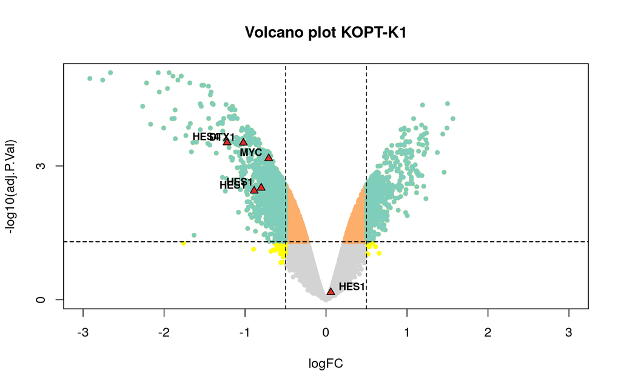

```r
# Extraemos columnas de interés
vulcano_data <- subset(array_toptable.annotated, select = c("GeneSymbol", "logFC", "P.Value", "adj.P.Val"))

# Cojo el mayor y menor valor de nuestros datos y le doy un margen
min_value <- min(vulcano_data$logFC)-0.5
max_value <- max(vulcano_data$logFC)+0.5
# mis limites se generaran en función del valor más grande en valor absoluto
myxlim <- round(max( -min_value, max_value))

# Make a basic volcano plot
with(vulcano_data, plot(logFC, -log10(adj.P.Val), pch=20,
                        main="Volcano plot KOPT-K1",
                        col = "lightgray",
                        xlim=c(-myxlim, myxlim),
                        xaxp = c(-5, 5, 10),
                        yaxp = c(0, 15, 5),
                        cex = 1))

# Add colored points: red if adj.P.Val<0.05, orange of log2FC>1.5, green if both)
with(subset(vulcano_data, adj.P.Val<.05), points(logFC, -log10(adj.P.Val), pch=20, col="#fdae6b", cex = 1))
with(subset(vulcano_data, abs(logFC)>0.5), points(logFC, -log10(adj.P.Val), pch=20, col="yellow", cex = 1))
with(subset(vulcano_data, adj.P.Val<.05 & abs(logFC)>0.5), points(logFC, -log10(adj.P.Val), pch=20, col="#7fcdbb", cex = 1))

# which(genesymbols %in% "MYC") # 5191
# which(genesymbols %in% "DTX1") # 9643
# which(genesymbols %in% "HES1") # 812, 834, 45900
genesymbols <- as.vector(vulcano_data$GeneSymbol)
# Colour gene selected
with(vulcano_data[c(which(genesymbols %in% "HES1"),
                    which(genesymbols %in% "MYC"),
                    which(genesymbols %in% "DTX1"),
                    which(genesymbols %in% "HES4")), ],
     points(logFC, -log10(adj.P.Val), pch = 24, bg = "#de2d26", col = "black", cex = 1))
# Creamos un vector con tantos elementos vacios como spots
mylabels <- rep("", 54675)
# Saco la lista de nombres de genes

# Añadimos la etiqueta deseada en la posición deseada
mylabels[which(genesymbols %in% "MYC")] <- "MYC"
mylabels[which(genesymbols %in% "DTX1")] <- "DTX1"
mylabels[which(genesymbols %in% "HES1")] <- "HES1"

mylabels[which(genesymbols %in% "HES4")] <- "HES4"


# Label points with the textxy function from the calibrate plot
library(calibrate)
with(subset(vulcano_data, adj.P.Val & abs(logFC)), textxy(logFC, -log10(adj.P.Val), labs = mylabels, cex=0.8, font = 2))

# Add limit dotted lines
abline (v = 0.5, lty = 2 )
abline (v = -0.5, lty = 2)
# obtengo el P valor asociado al adj.P.valor < 0.05 empleado como corte
abline (h = -log10(tail(vulcano_data[ vulcano_data$adj.P.Val < 0.05 , ]$adj.P.Val)), lty = 2)
```

```r
# Numero de genes sobre-expresados con p-valor ajustado < 0.05 y logFC > 1
dim(vulcano_data[ vulcano_data$adj.P.Val < 0.05 & vulcano_data$logFC > 0.5 , ])
```

```
## [1] 576   4
```

```r
# Numero de genes sub-expresados con p-valor ajustado < 0.05 y logFC < 1
dim(vulcano_data[ vulcano_data$adj.P.Val < 0.05 & vulcano_data$logFC < -0.5, ])
```

```
## [1] 1579    4
```

## 4.6 Clusterizacion

Creamos los archivos para la clusterización para Morpheus

```r
# genes diferencialmente expresados
diff_genes <- unique(rownames(vulcano_data[ vulcano_data$adj.P.Val < 0.05 , ] ))

# length(diff_genes) # 20828
exprseset_KOPT_diff <- exprseset_KOPT[rownames(exprseset_control) %in% diff_genes, ]

# Cambiamos los nombres de las muestras
colnames(exprseset_KOPT_diff) <- c("DMSO_01", "DMSO_02", "DMSO_03", "SAMH1_01", "SAMH1_02", "SAMH1_03")

# Nombre de los spots
spots_KOPT_diff <- rownames(exprseset_KOPT_diff)

spots_KOPT_diff_list.GeneSymbol <- as.list(mapIds(hgu133plus2.db, keys=spots_KOPT_diff, column="SYMBOL", keytype = "PROBEID"))
spots_KOPT_diff_char.GeneSymbol <- as.character(spots_KOPT_diff_list.GeneSymbol)

# Añadimos al data frame la columna con los nombres de los genes
exprseset_KOPT_diff.annotated<-cbind(exprseset_KOPT_diff, spots_KOPT_diff_char.GeneSymbol)

# Change name column added
colnames(exprseset_KOPT_diff.annotated)[length(colnames(exprseset_KOPT_diff.annotated))] <- "Description"


# Reordering colnumns by positions. We want "Gene_names" as the second column

exprseset_KOPT_diff.annotated <-exprseset_KOPT_diff.annotated[, c("Description", "DMSO_01", "DMSO_02", "DMSO_03",
                                                                  "SAMH1_01", "SAMH1_02", "SAMH1_03")]
head(exprseset_KOPT_diff.annotated$Description)
```

```
## [1] PXK      PXK      ZDHHC11  ATP6V1E2 AFG3L1P  PIGX
## 4736 Levels: A1BG A2MP1 AAK1 AARS1 AASDHPPT ABAT ABCA11P ABCA5 ABCB10 ... ZZZ3
```

```r
# write.csv(exprseset_KOPT_diff.annotated, file = "KOPT_diff_top_35.csv")
```

## 4.7 Análisis funcional: PANTHER y Babelomics

Creamos la lista de genes que emplearemos en el análisis funcional con PANTHER y Babelomics 5.0.

```r
# Genes sub-expresados
KOPT_sub <- vulcano_data[ vulcano_data$adj.P.Val < 0.05
                          & vulcano_data$logFC < -0.5, ]
# Eliminamos los NA y seleccionamos los 170 top de la 1 columna (GENESYMBOL)
KOPT_sub <- KOPT_sub[complete.cases(KOPT_sub), ][0:170, 1]
# exprseset_KOPT_diff.annotated$Description[complete.cases(exprseset_KOPT_diff.annotated$Description)]
write.csv(KOPT_sub, file = "KOPT_sub_170.csv",
          row.names = FALSE)

# Genes sobre-expresados
KOPT_over <- vulcano_data[ vulcano_data$adj.P.Val < 0.05 &
                             vulcano_data$logFC > 0.5 , ]

# Eliminamos los NA y seleccionamos los 170 top de la 1 columna (GENESYMBOL)
KOPT_over <- KOPT_over[complete.cases(KOPT_over), ][0:170, 1]
write.csv(KOPT_over, file = "KOPT_over_170.csv",
          row.names = FALSE)
```

## 4.8 Línea celular HPB-ALL

- HPB-ALL_DMSO $\rightarrow$ “GSM455118.CEL”, “GSM455119.CEL”, “GSM455120.CEL”
- HPB-ALL_SAHM1 $\rightarrow$ “GSM455124.CEL”, “GSM455125.CEL”, “GSM455126.CEL”

## 4.9 Cargamos los ficheros .CEL y extraemos el raw data

```r
# Read .CEL files
# data <- ReadAffy(filenames=targets$FileName)
CELfiles_HPB <- c("GSM455118.CEL", "GSM455119.CEL", "GSM455120.CEL", "GSM455124.CEL", "GSM455125.CEL", "GSM455126.CEL")

rawdata_HPB <- ReadAffy(filenames = CELfiles_HPB)
rawdata_HPB
```

```
## AffyBatch object
## size of arrays=1164x1164 features (20 kb)
## cdf=HG-U133_Plus_2 (54675 affyids)
## number of samples=6
## number of genes=54675
## annotation=hgu133plus2
## notes=
```

## 4.10 Análisis exploratorio de la calidad de los datos iniciales

### 4.10.1 Distribución de las intensidades antes de normalizar

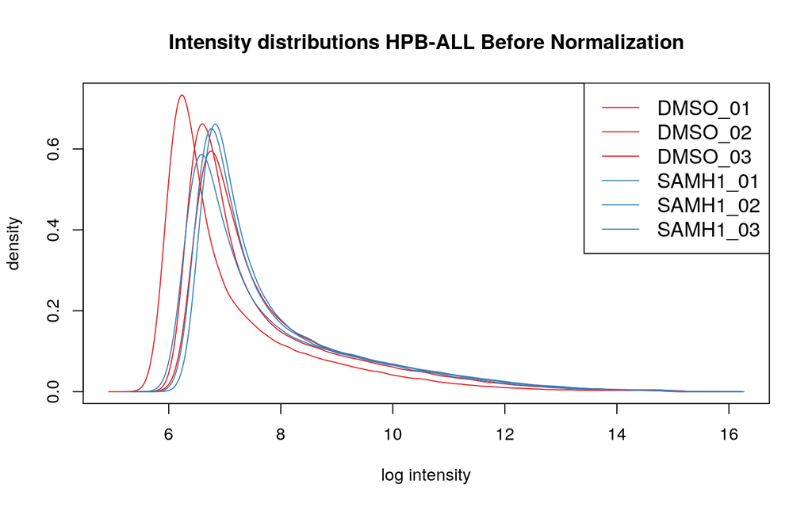

```r
#########################
# Intensity distributions
#########################

# Show intensity distributrions with hist function
hist(rawdata_HPB, lty = rep(1, length(CELfiles_KOPT)), col = mycols,
   main = "Intensity distributions HPB-ALL Before Normalization")

# Add legend in the top right corner
legend("topright", c("DMSO_01", "DMSO_02", "DMSO_03",
                              "SAMH1_01", "SAMH1_02", "SAMH1_03"),
       lty = rep(1, length(CELfiles_HPB)),
       col = mycols,
       cex = 1.2)
```

### 4.10.2 Boxplot antes de normalizar

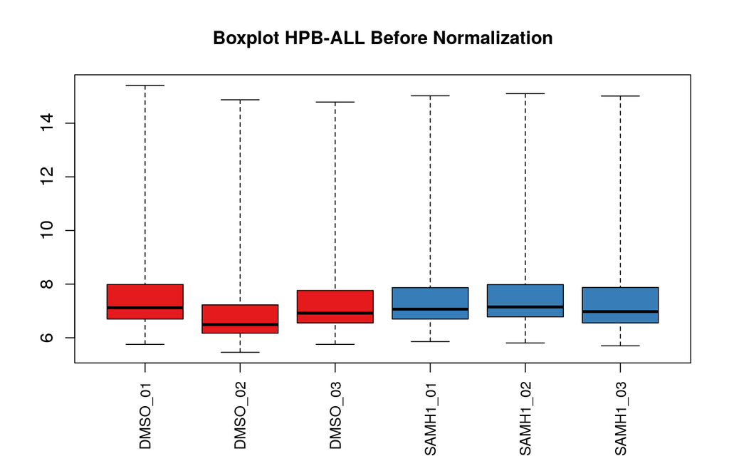

```r
#############################
# boxplot antes de normalizar
#############################

boxplot(rawdata_HPB,
        main="Boxplot HPB-ALL Before Normalization",
        col = mycols,
        names =  c("DMSO_01", "DMSO_02", "DMSO_03",
                              "SAMH1_01", "SAMH1_02", "SAMH1_03"),
        las = 2,  # vertical labels
        cex.axis = 0.97, # size labels
        yaxt = "n") # do not show y labels
axis(2, cex.axis = 1.2) # plot y labels with higher size
```

## 4.11 Normalización con RMA

```r
eset_HPB <- expresso(rawdata_HPB,
                 bg.correct = TRUE,
                 bgcorrect.method="rma", # corregir fondo
                 normalize = TRUE,
                 normalize.method="quantiles",
                 pmcorrect.method="pmonly", # los que machean perfectamente
                 summary.method="medianpolish", # resumeme por la mediana par aun mismo gen
                 verbose = TRUE,
)
```

```
## background correction: rma
## normalization: quantiles
## PM/MM correction : pmonly
## expression values: medianpolish
## background correcting...done.
## normalizing...done.
## 54675 ids to be processed
## |                    |
## |####################|
```

### 4.11.1 Distribución de la intensidad tras la normalización

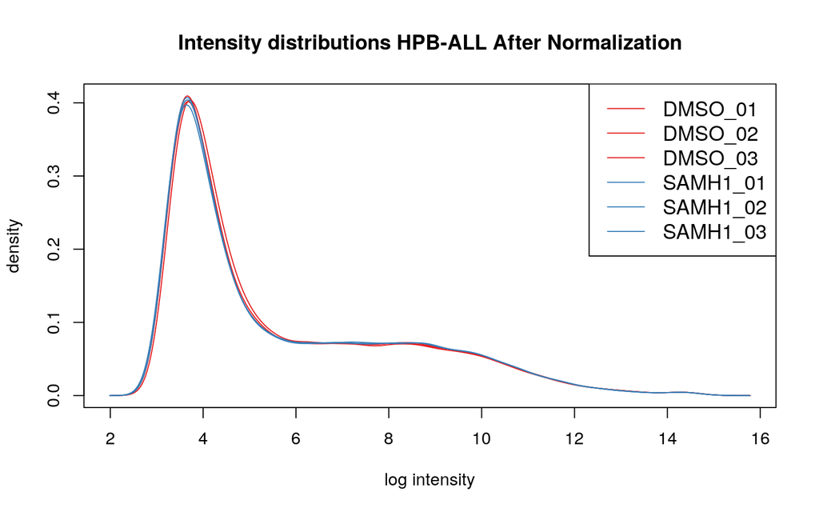

```r
#########################
# Intensity distributions
#########################

# Show intensity distributrions
exprseset_HPB <- as.data.frame(exprs(eset_HPB)) # cojo las intensidades normalizadas
dens_HPB <- apply(data.frame(exprseset_HPB), 2, density)

plot(NA, xlim=range(sapply(dens_HPB, "[", "x")), ylim=range(sapply(dens_HPB, "[", "y")),
     main = "Intensity distributions HPB-ALL After Normalization",
     xlab = "log intensity", ylab = "density")
distribution_HPB <- mapply(lines, dens_HPB, col=c(rep(mycols[1], 3), rep(mycols[4], 3)), lwd = 1)

# Add legend in the top right corner
legend("topright", legend= c("DMSO_01", "DMSO_02", "DMSO_03",
                              "SAMH1_01", "SAMH1_02", "SAMH1_03"),
       lty = rep(1, length(CELfiles_HPB)), col = mycols, cex = 1.2)
```

### 4.11.2 Boxplots tras la normalización

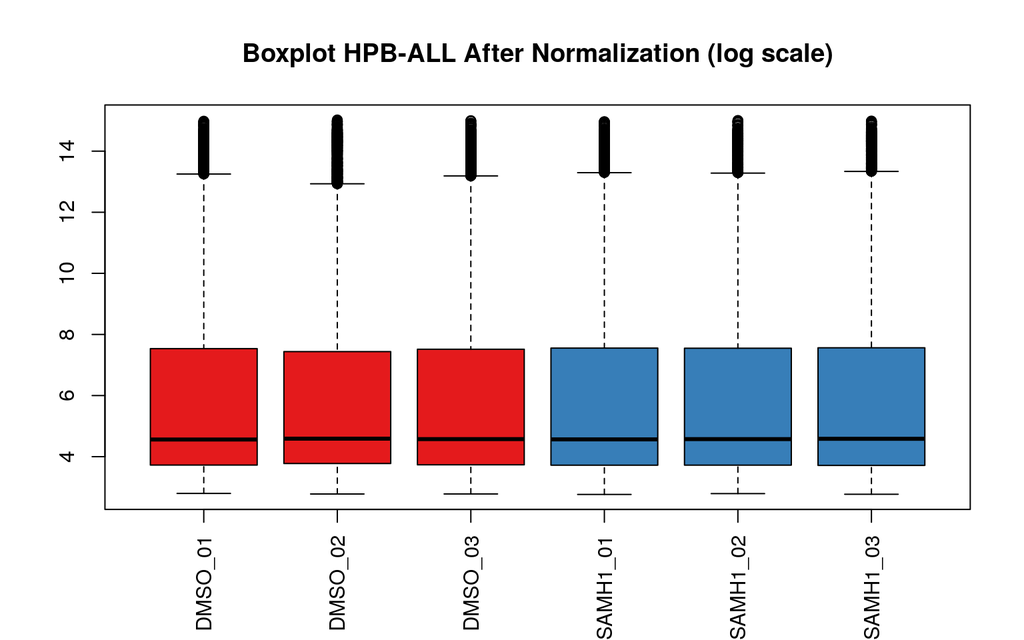

```r
# boxplot de todos los genes después de normalizar
boxplot(data.frame(exprseset_HPB),
        main="Boxplot HPB-ALL After Normalization (log scale)",
        col = mycols,
        names =  c("DMSO_01", "DMSO_02", "DMSO_03",
                              "SAMH1_01", "SAMH1_02", "SAMH1_03"),
        las = 2,  # vertical labels
        cex.axis = 0.97, # size labels
        yaxt = "n") # do not show y labels
axis(2, cex.axis = 1) # plot y labels with higher size
```

### 4.11.3 Scatter-plot y MA-plot tras la normalización

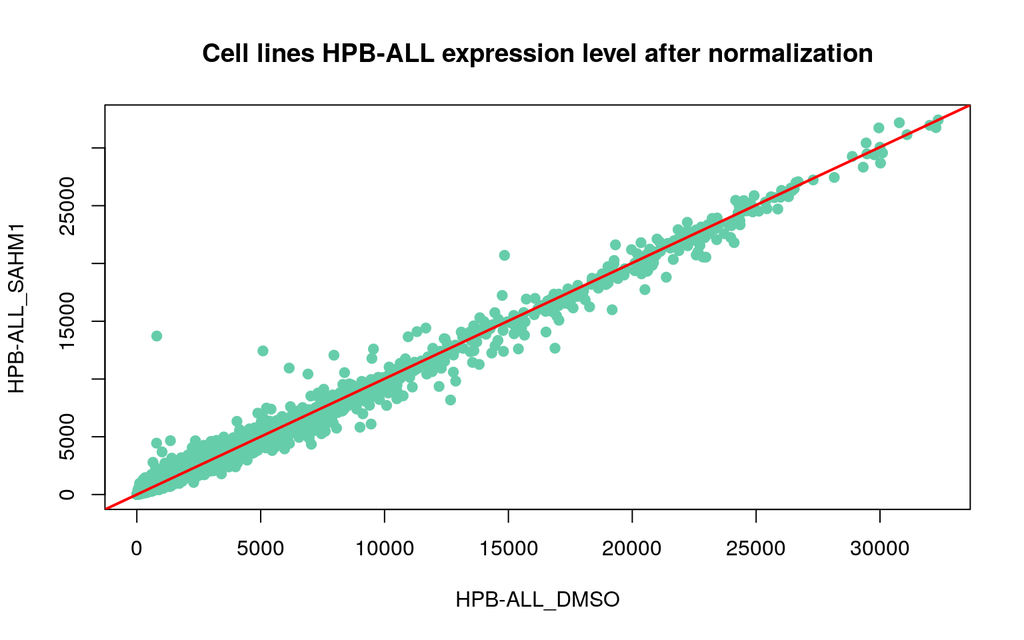

```r
# Note that the original eset object contains the log2-transformed gene intensities
intens_HPB = 2^exprseset_HPB # transform from log2 to normal intensity

# Create reference median array for each cell line to compare
# median intensity for KOPT-K1 control DMSO
intens_HPB_DMSO = apply(intens_HPB[, c(1, 2, 3)], 1, median)
# median intensity for HPB-ALL control DMSO
intens_HPB_SAHM1 = apply(intens_HPB[, c(4, 5, 6)], 1, median)

plot(intens_HPB_DMSO, intens_HPB_SAHM1, cex = 1,
     pch = 19, col = "mediumaquamarine",
     xlab = "HPB-ALL_DMSO",
     ylab = "HPB-ALL_SAHM1",
     main = "Cell lines HPB-ALL expression level after normalization")

abline(a = 0,
       b = (max(intens_HPB_SAHM1) / max(intens_HPB_DMSO)), col = "red",
       lwd = 2)
```

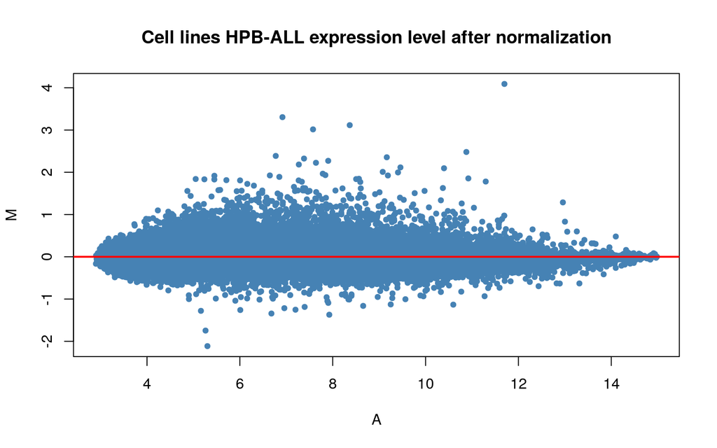

```r
A <- 1/2*log2(intens_HPB_SAHM1*intens_HPB_DMSO)
M <- log2(intens_HPB_SAHM1/intens_HPB_DMSO)
plot(A, M, cex = 0.75, pch = 19, col = "steelblue",
     main = "Cell lines HPB-ALL expression level after normalization")

abline(h = 0, col = "red", lty = 1, lwd = 2)
```

En esta línea celular vemos que hay genes subregulados y sobre regulados en la línea SAHM1 con respecto el control.

### 4.11.4 PCA

```r
PCA_g <- prcomp(t(exprs(eset_HPB)))
rownames(PCA_g$x) <- c("DMSO_01", "DMSO_02", "DMSO_03",
                              "SAMH1_01", "SAMH1_02", "SAMH1_03")
summary(PCA_g)
```

```
## Importance of components:
##                            PC1     PC2     PC3     PC4      PC5       PC6
## Standard deviation     29.5646 16.1962 14.2579 13.5222 12.41221 1.245e-13
## Proportion of Variance  0.5213  0.1565  0.1212  0.1091  0.09189 0.000e+00
## Cumulative Proportion   0.5213  0.6778  0.7991  0.9081  1.00000 1.000e+00
```

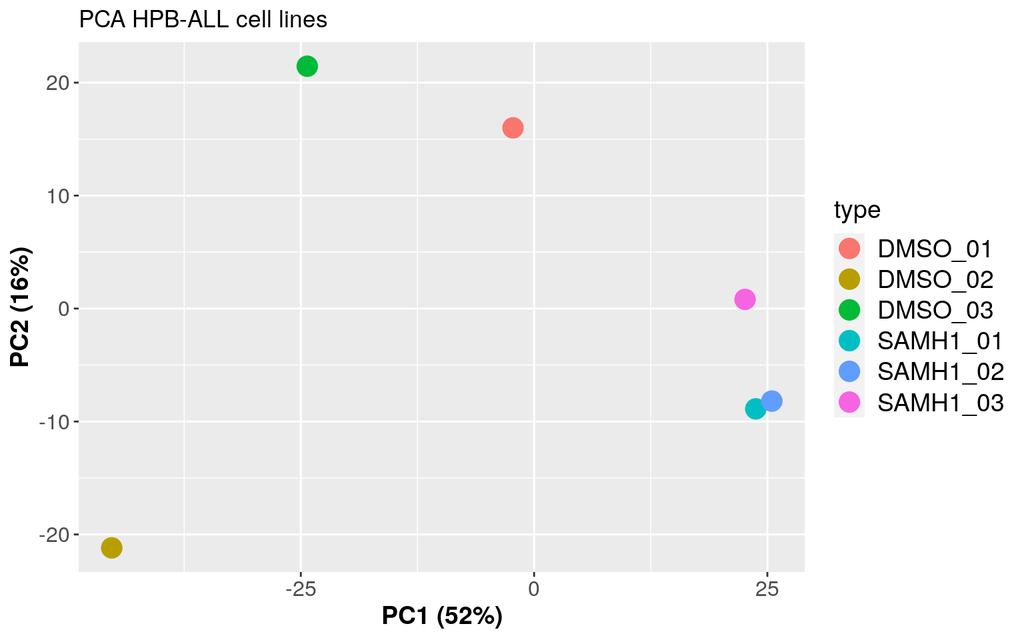

```r
pc_dat<- data.frame(type = rownames(PCA_g$x), PC1 = PCA_g$x[,1], PC2=PCA_g$x[,2])
library(ggplot2)
ggplot(pc_dat,aes(x=PC1, y=PC2, col=type)) + geom_point(size = 5) + theme(
  legend.title = element_text(color = "black", size = 14),
  legend.text = element_text(color = "black" , size = 14),
  axis.text=element_text(size=12),
  axis.title=element_text(size=14,face="bold")) + xlab("PC1 (52%)") + ylab("PC2 (16%)") +
  ggtitle("PCA HPB-ALL cell lines")
```

### 4.11.5 Filtro del rango intercuartílico

```r
# boxplot de solo los genes normalizados con un ranog intercuartílico superior a 0.5 para que tengan variabilidad
esetIQR_HPB <- varFilter(eset_HPB, var.func=IQR, var.cutoff=0.5, filterByQuantile=TRUE)

## Comprobamos el filtro del rango intercuartílico
dim(exprs(eset_HPB))
```

```
## [1] 54675     6
```

```r
dim(exprs(esetIQR_HPB))
```

```
## [1] 27337     6
```

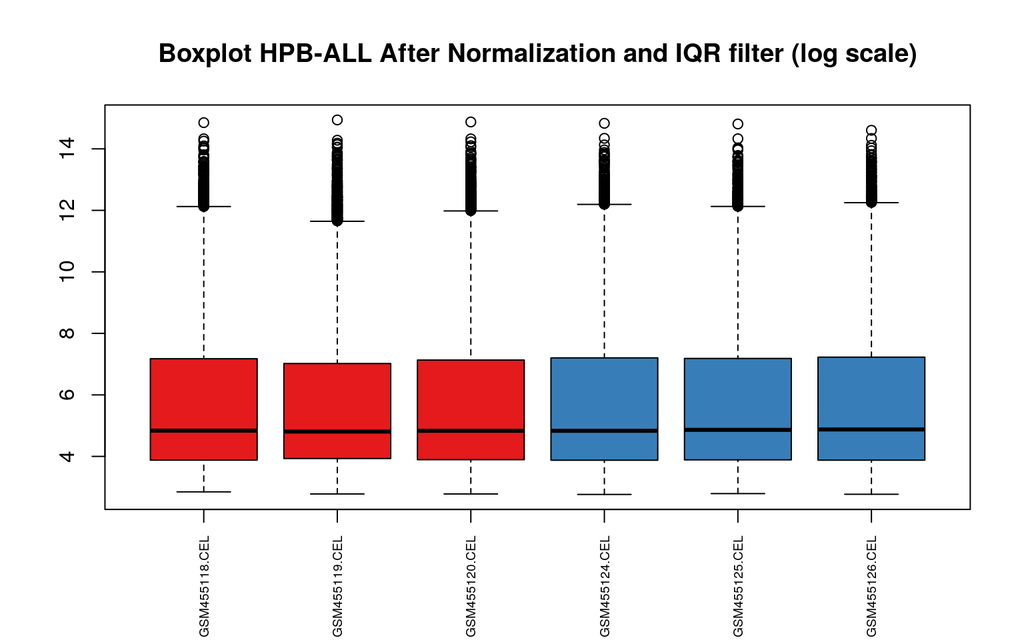

```r
# boxplot de solo los genes normalizados con un ranog intercuartílico superior a 0.5 para que tengan variabilidad
exprsesetIQR_HPB <- as.data.frame(exprs(esetIQR_HPB))

boxplot(data.frame(exprsesetIQR_HPB),
        main="Boxplot HPB-ALL After Normalization and IQR filter (log scale)",
        col = mycols,
        names = sampleNames(rawdata_HPB),
        las = 2,  # vertical labels
        cex.axis = 0.6, # size labels
        yaxt = "n") # do not show y labels
axis(2, cex.axis = 1) # plot y labels with higher size
```

## 4.12 Expresión diferencial

### 4.12.1 Análisis estadístico

Generamos la matriz donde guardaremos el diseño experimental que empleará *makeContrast* para realizar la comparación de niveles de transcripción. A cada archivo .CEL le asigno un número en función del tratamiento y línea celular.

- HPB-ALL_DMSO $\rightarrow$ 1
- HPB-ALL_SAHM1 $\rightarrow$ 2

```r
# Generamos la matriz de diseño experimental
design_HPB <- model.matrix(~ 0+factor(c(1,1,1,2,2,2)))
rownames(design_HPB)<-sampleNames(rawdata_HPB)
colnames(design_HPB) <- c("HPB_DMSO", "HPB_SAHM1")

# Mostramos la matriz de diseño experimental
design_HPB
```

```
##               HPB_DMSO HPB_SAHM1
## GSM455118.CEL        1         0
## GSM455119.CEL        1         0
## GSM455120.CEL        1         0
## GSM455124.CEL        0         1
## GSM455125.CEL        0         1
## GSM455126.CEL        0         1
## attr(,"assign")
## [1] 1 1
## attr(,"contrasts")
## attr(,"contrasts")$`factor(c(1, 1, 1, 2, 2, 2))`
## [1] "contr.treatment"
```

Realizamos el ajuste de cada grupo a una recta y realizamos el estudio de expresión diferencial empleando la función *makeContrast*

```r
## ajustamos cada nube de puntos correspondiente a cada grupo a una recta
fit_HPB <- lmFit(esetIQR_HPB, design_HPB)

## establecemos las comparaciones que queremos realizar
## Tenemos que dividir entre 2 para que tengan todos el mismo peso. Las dos últimas no tienen ningún sentido
contrast.matrix_HPB <- makeContrasts(HPB_SAHM1 - HPB_DMSO, levels=design_HPB)

## comparamos las regresiones lineales según el patrón de contraste pedido
fit2_HPB <- contrasts.fit(fit_HPB, contrast.matrix_HPB)

fit2_HPB <- eBayes(fit2_HPB)
```

```r
#Table with DEGs results number te cogerá todos los genes (filas) que tenia esetIQR

toptableIQR_HPB<-topTable(fit2_HPB, number=dim(exprs(esetIQR_HPB))[1],
                              adjust.method="BH", coef = 1,  sort.by="p")
# para poder ordenar por "p" necesito poner el coeficiente, es decir, que sepa que comparación debe coger

head(toptableIQR_HPB)
```

```
##                 logFC  AveExpr         t      P.Value    adj.P.Val        B
## 201466_s_at  2.133393 7.287055  16.59107 7.714196e-11 2.108830e-06 13.76959
## 201464_x_at  1.554185 8.055113  13.73944 1.020585e-09 7.688286e-06 11.84766
## 229147_at    1.645832 6.494138  13.70343 1.057501e-09 7.688286e-06 11.81985
## 230710_at   -1.976149 5.244433 -13.64094 1.124964e-09 7.688286e-06 11.77135
## 201465_s_at  2.274361 6.747899  13.10716 1.927464e-09 1.053822e-05 11.34469
## 225342_at   -2.107886 5.313215 -12.86431 2.477920e-09 1.128982e-05 11.14298
```

```r
dim((toptableIQR_HPB))
```

```
## [1] 27337     6
```

Ahora quiero quedarme solo con los genes que cumplan un FDR<0.05 (adjusted P-value)

```r
# Data frame with the values of the spot
HPB.fdr.005.table<-subset(toptableIQR_HPB,
                              toptableIQR_HPB$adj.P.Val<=0.05)
dim(HPB.fdr.005.table)
```

```
## [1] 2105    6
```

```r
summary(HPB.fdr.005.table) ##  Check the maximum adj.P.val is < 0.05
```

```
##      logFC            AveExpr             t              P.Value
##  Min.   :-2.1079   Min.   : 3.497   Min.   :-13.641   Min.   :0.0000000
##  1st Qu.:-0.4516   1st Qu.: 5.962   1st Qu.: -3.654   1st Qu.:0.0002426
##  Median : 0.5002   Median : 7.301   Median :  3.731   Median :0.0009723
##  Mean   : 0.2794   Mean   : 7.462   Mean   :  1.581   Mean   :0.0013067
##  3rd Qu.: 0.6788   3rd Qu.: 8.827   3rd Qu.:  4.478   3rd Qu.:0.0022161
##  Max.   : 3.2172   Max.   :14.106   Max.   : 16.591   Max.   :0.0038494
##    adj.P.Val               B
##  Min.   :2.110e-06   Min.   :-1.98188
##  1st Qu.:1.258e-02   1st Qu.:-1.45203
##  Median :2.524e-02   Median :-0.65773
##  Mean   :2.559e-02   Mean   :-0.08591
##  3rd Qu.:3.835e-02   3rd Qu.: 0.68514
##  Max.   :4.999e-02   Max.   :13.76959
```

Hemos pasado de 54675 genes iniciales a 27337 tras el filtro IR y, finalmente, a 2105 genes tras el filtro de FDR.

## 4.13 Incorporación de los nombres de los genes

Queremos incorporar anotaciones a *HPB.fdr.005.table*

```r
library("hgu133plus2.db")
```

```r
# Recuperamos los nombres de las sondas de los diferentes spots del microarray
HPB_probenames.fdr.005<-as.character(rownames(HPB.fdr.005.table))
head(HPB_probenames.fdr.005)
```

```
## [1] "201466_s_at" "201464_x_at" "229147_at"   "230710_at"   "201465_s_at"
## [6] "225342_at"
```

```r
# Recuperamos la lista de genes asociados a las diferentes sondas del microarray
HPB_list.GeneSymbol.fdr.005<-mget(HPB_probenames.fdr.005, hgu133plus2SYMBOL)
head(HPB_list.GeneSymbol.fdr.005)
```

```
## $`201466_s_at`
## [1] "JUN"
##
## $`201464_x_at`
## [1] "JUN"
##
## $`229147_at`
## [1] "RASSF6"
##
## $`230710_at`
## [1] "MIR210HG"
##
## $`201465_s_at`
## [1] "JUN"
##
## $`225342_at`
## [1] "AK4"
```

```r
# ahora mostrmos solo los nombres de los genes
HPB_char.GeneSymbol.fdr.005<- as.character(HPB_list.GeneSymbol.fdr.005)
head(HPB_char.GeneSymbol.fdr.005)
```

```
## [1] "JUN"      "JUN"      "RASSF6"   "MIR210HG" "JUN"      "AK4"
```

```r
# Añadimos al data frame la columna con los nombres de los genes
HPB_toptable.annotated<-cbind(HPB.fdr.005.table, HPB_char.GeneSymbol.fdr.005)
head(HPB_toptable.annotated)
```

```
##                 logFC  AveExpr         t      P.Value    adj.P.Val        B
## 201466_s_at  2.133393 7.287055  16.59107 7.714196e-11 2.108830e-06 13.76959
## 201464_x_at  1.554185 8.055113  13.73944 1.020585e-09 7.688286e-06 11.84766
## 229147_at    1.645832 6.494138  13.70343 1.057501e-09 7.688286e-06 11.81985
## 230710_at   -1.976149 5.244433 -13.64094 1.124964e-09 7.688286e-06 11.77135
## 201465_s_at  2.274361 6.747899  13.10716 1.927464e-09 1.053822e-05 11.34469
## 225342_at   -2.107886 5.313215 -12.86431 2.477920e-09 1.128982e-05 11.14298
##             HPB_char.GeneSymbol.fdr.005
## 201466_s_at                         JUN
## 201464_x_at                         JUN
## 229147_at                        RASSF6
## 230710_at                      MIR210HG
## 201465_s_at                         JUN
## 225342_at                           AK4
```

### 4.13.1 Vulcano plot

```r
## ajustamos cada nube de puntos correspondiente a cada grupo a una recta
fit_HPB_completo <- lmFit(eset_HPB, design_HPB)

## establecemos las comparaciones que queremos realizar
contrast.matrix_completo_HPB <- makeContrasts(HPB_SAHM1- HPB_DMSO , levels=design_HPB)

## comparamos las regresiones lineales según el patrón de contraste pedido
fit2_HPB_completo <- contrasts.fit(fit_HPB_completo, contrast.matrix_completo_HPB)

fit2_HPB_completo<-eBayes(fit2_HPB_completo )

#Table with DEGs results number te cogerá todos los genes (filas) que tenia esetIQR

toptable_HPB_completo <-topTable(fit2_HPB_completo, number=dim(exprs(eset_HPB))[1],
                              adjust.method="BH", coef = 1,  sort.by="p")
```

Añadimos los nombres de los genes a todos los spots del microarray

```r
# Using the aternatively method
# if you wanted to extract only one column of data you could instead use themapIds method
library("hgu133plus2.db")
array_probenames <- as.character(rownames(toptable_HPB_completo))
array_list.GeneSymbol <- as.list(mapIds(hgu133plus2.db, keys=array_probenames, column="SYMBOL", keytype = "PROBEID"))
# Extraigo los nombres de los genes
array_char.GeneSymbol <- as.character(array_list.GeneSymbol)

# Añadimos al data frame la columna con los nombres de los genes
array_toptable.annotated<-cbind(toptable_HPB_completo, array_char.GeneSymbol)

# Change name column added
colnames(array_toptable.annotated)[length(colnames(array_toptable.annotated))] <- "GeneSymbol"

head(array_toptable.annotated)
```

```
##                logFC  AveExpr        t      P.Value    adj.P.Val        B
## 201464_x_at 1.554185 8.055113 24.08560 9.132163e-09 0.0004993010 8.810910
## 201466_s_at 2.133393 7.287055 20.40441 3.386351e-08 0.0008437449 8.157748
## 229147_at   1.645832 6.494138 19.51476 4.810628e-08 0.0008437449 7.962599
## 219270_at   1.336272 6.227070 18.90576 6.172802e-08 0.0008437449 7.818805
## 202672_s_at 1.348140 8.400887 17.69421 1.038080e-07 0.0011351402 7.505175
## 209921_at   1.133332 8.556416 16.05874 2.216032e-07 0.0016316341 7.014503
##             GeneSymbol
## 201464_x_at        JUN
## 201466_s_at        JUN
## 229147_at       RASSF6
## 219270_at        CHAC1
## 202672_s_at       ATF3
## 209921_at      SLC7A11
```

Ahora sí, procedemos a realizar el vulcano plot. Extraemos primero las columnas de interés para facilitar el manejo de los datos. Seleccionamos los genes que muestran un P valor ajustado menor que 0.05 para ser coloreados y se plotean en función de su P valor.

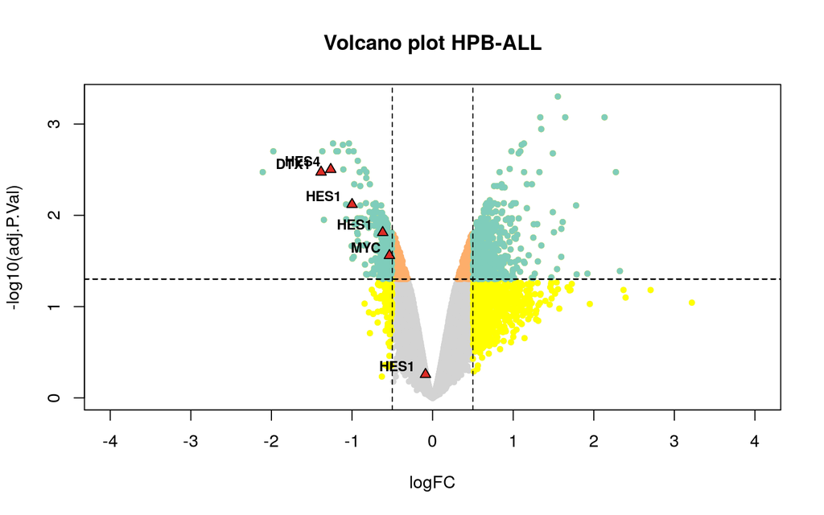

```r
# Extraemos columnas de interés
vulcano_data <- subset(array_toptable.annotated, select = c("GeneSymbol", "logFC", "P.Value", "adj.P.Val"))

# Cojo el mayor y menor valor de nuestros datos y le doy un margen
min_value <- min(vulcano_data$logFC)-0.5
max_value <- max(vulcano_data$logFC)+0.5
# mis limites se generaran en función del valor más grande en valor absoluto
myxlim <- round(max( -min_value, max_value))

# Make a basic volcano plot
with(vulcano_data, plot(logFC, -log10(adj.P.Val), pch=20,
                        main="Volcano plot HPB-ALL",
                        col = "lightgray",
                        xlim=c(-myxlim, myxlim),
                        xaxp = c(-5, 5, 10),
                        yaxp = c(0, 4, 4),
                        cex = 1))

# Add colored points: red if adj.P.Val<0.05, orange of log2FC>1.5, green if both)
with(subset(vulcano_data, adj.P.Val<.05), points(logFC, -log10(adj.P.Val), pch=20, col="#fdae6b", cex = 1))
with(subset(vulcano_data, abs(logFC)>0.5), points(logFC, -log10(adj.P.Val), pch=20, col="yellow", cex = 1))
with(subset(vulcano_data, adj.P.Val<.05 & abs(logFC)>0.5), points(logFC, -log10(adj.P.Val), pch=20, col="#7fcdbb", cex = 1))

# which(genesymbols %in% "MYC") # 5191
# which(genesymbols %in% "DTX1") # 9643
# which(genesymbols %in% "HES1") # 812, 834, 45900
genesymbols <- as.vector(vulcano_data$GeneSymbol)
# Colour gene selected
with(vulcano_data[c(which(genesymbols %in% "HES1"),
                    which(genesymbols %in% "MYC"),
                    which(genesymbols %in% "DTX1"),
                    which(genesymbols %in% "HES4")), ],
     points(logFC, -log10(adj.P.Val), pch = 24, bg = "#de2d26", col = "black", cex = 1))
# Creamos un vector con tantos elementos vacios como spots
mylabels <- rep("", 54675)
# Saco la lista de nombres de genes

# Añadimos la etiqueta deseada en la posición deseada
mylabels[which(genesymbols %in% "MYC")] <- "MYC"
mylabels[which(genesymbols %in% "DTX1")] <- "DTX1"
mylabels[which(genesymbols %in% "HES1")] <- "HES1"

mylabels[which(genesymbols %in% "HES4")] <- "HES4"


# Label points with the textxy function from the calibrate plot
library(calibrate)
with(subset(vulcano_data, adj.P.Val & abs(logFC)), textxy(logFC, -log10(adj.P.Val), labs = mylabels, cex=0.8, font = 2))

# Add limit dotted lines
abline (v = 0.5, lty = 2 )
abline (v = -0.5, lty = 2)
# obtengo el P valor asociado al adj.P.valor < 0.05 empleado como corte
abline (h = -log10(tail(vulcano_data[ vulcano_data$adj.P.Val < 0.05 , ]$adj.P.Val)), lty = 2)
```

```r
# Numero de genes sobre-expresados con p-valor ajustado < 0.05 y logFC > 1
dim(vulcano_data[ vulcano_data$adj.P.Val < 0.05 & vulcano_data$logFC > 0.5 , ])
```

```
## [1] 495   4
```

```r
# Numero de genes sub-expresados con p-valor ajustado < 0.05 y logFC < 1
dim(vulcano_data[ vulcano_data$adj.P.Val < 0.05 & vulcano_data$logFC < -0.5, ])
```

```
## [1] 297   4
```

## 4.14 Clusterizacion

Creamos los archivos para la clusterización por Morpheus

```r
# genes diferencialmente expresados
diff_genes <- unique(rownames(vulcano_data[ vulcano_data$adj.P.Val < 0.05 , ] ))

# length(diff_genes) # 20828
exprseset_HPB_diff <- exprseset_HPB[rownames(exprseset_control) %in% diff_genes, ]

# Cambiamos los nombres de las muestras
colnames(exprseset_HPB_diff) <- c("DMSO_01", "DMSO_02", "DMSO_03", "SAMH1_01", "SAMH1_02", "SAMH1_03")

# Nombre de los spots
spots_HPB_diff <- rownames(exprseset_HPB_diff)

spots_HPB_diff_list.GeneSymbol <- as.list(mapIds(hgu133plus2.db, keys=spots_HPB_diff, column="SYMBOL", keytype = "PROBEID"))
spots_HPB_diff_char.GeneSymbol <- as.character(spots_HPB_diff_list.GeneSymbol)

# Añadimos al data frame la columna con los nombres de los genes
exprseset_HPB_diff.annotated<-cbind(exprseset_HPB_diff, spots_HPB_diff_char.GeneSymbol)

# Change name column added
colnames(exprseset_HPB_diff.annotated)[length(colnames(exprseset_HPB_diff.annotated))] <- "Description"


# Reordering colnumns by positions. We want "Gene_names" as the second column

exprseset_HPB_diff.annotated <-exprseset_HPB_diff.annotated[, c("Description", "DMSO_01", "DMSO_02", "DMSO_03",
                                                                  "SAMH1_01", "SAMH1_02", "SAMH1_03")]
head(exprseset_HPB_diff.annotated)
```

```
##              Description  DMSO_01  DMSO_02  DMSO_03 SAMH1_01 SAMH1_02 SAMH1_03
## 1487_at            ESRRA 7.225326 7.529680 7.564784 6.875405 6.891771 6.996000
## 1552257_a_at      TTLL12 9.385135 9.734830 9.718359 9.117345 9.069209 8.827111
## 1552315_at        GIMAP1 5.701511 5.728656 5.708618 5.148787 5.143014 5.264291
## 1552316_a_at      GIMAP1 7.531630 7.430081 7.441481 7.009130 7.184310 7.097591
## 1552370_at       C4orf33 7.399771 7.642196 7.421658 7.951080 7.956657 8.039872
## 1552474_a_at        GAMT 8.618665 8.830208 8.786910 8.321608 8.028638 8.300437
```

```r
write.csv(exprseset_HPB_diff.annotated, file = "HPB_diff.csv")
```

## 4.15 Análisis funcional: PANTHER y Babelomics

Creamos la lista de genes que emplearemos en el análisis funcional con PANTHER y Babelomics 5.0.

```r
# Genes sub-expresados
HPB_sub <- vulcano_data[ vulcano_data$adj.P.Val < 0.05
                          & vulcano_data$logFC < -0.5, ]
# Eliminamos los NA y seleccionamos los 170 top de la 1 columna (GENESYMBOL)
HPB_sub <- HPB_sub[complete.cases(HPB_sub), ][0:170, 1]
write.table(HPB_sub, file = "HPB_sub_170.csv",
          row.names = FALSE, col.names = FALSE, sep = ",", quote = FALSE)

# Genes sobre-expresados
HPB_over <- vulcano_data[ vulcano_data$adj.P.Val < 0.05 &
                             vulcano_data$logFC > 0.5 , ]

# Eliminamos los NA y seleccionamos los 170 top de la 1 columna (GENESYMBOL)
HPB_over <- HPB_over[complete.cases(HPB_over), ][0:170, 1]
write.table(HPB_over, file = "HPB_over_170.csv",
          row.names = FALSE, col.names = FALSE, sep = ",", quote = FALSE)
```

# 5 GSEA

Aquí guardamos en archivos **.csv** los resultados de los arrays de las distintas líneas celulares conjuntamente para llevar a cabo el análisis GSEA.

```r
# Read .CEL files
rawdata_total <- ReadAffy()
rawdata_total
```

```
## AffyBatch object
## size of arrays=1164x1164 features (23 kb)
## cdf=HG-U133_Plus_2 (54675 affyids)
## number of samples=12
## number of genes=54675
## annotation=hgu133plus2
## notes=
```

```r
# Normalizo todo conjuntamente
eset_total <- expresso(rawdata_total,
                 bg.correct = TRUE,
                 bgcorrect.method="rma", # corregir fondo
                 normalize = TRUE,
                 normalize.method="quantiles",
                 pmcorrect.method="pmonly", # los que machean perfectamente
                 summary.method="medianpolish", # resumeme por la mediana par aun mismo gen
                 verbose = TRUE,
)
```

```
## background correction: rma
## normalization: quantiles
## PM/MM correction : pmonly
## expression values: medianpolish
## background correcting...done.
## normalizing...done.
## 54675 ids to be processed
## |                    |
## |####################|
```

Affymetrix data will usually be normalized using the affy package. We will assume here that thedata is available as anExpressionSetobject calledeset. Such an object will have an slot containingthe log-expression values for each gene on each array which can be extracted using exprs(eset).

```r
# Extraigo las intensidades de cada muestra normalizada
intens_total <- exprs(eset_total)
colnames(intens_total) <- c("KOPT-K1_DMSO_01", "KOPT-K1_DMSO_02", "KOPT-K1_DMSO_03", "HPB-ALL_DMSO_01", "HPB-ALL_DMSO_02", "HPB-ALL_DMSO_03", "KOPT-K1_SAMH1_01", "KOPT-K1_SAMH1_02", "KOPT-K1_SAMH1_03", "HPB-ALL_SAMH1_01", "HPB-ALL_SAMH1_02", "HPB-ALL_SAMH1_03")

# Obtengo la media de los controles DMSO
media_controles <- apply(intens_total[, c(1:6)], 1,  mean)

# Divido las muestras por la media de los controles
intens_norm_total <- intens_total # <- apply(intens_total, 2, function(sample){sample/media_controles})
```

```r
write.table(intens_norm_total, quote = FALSE, sep = "\t", file = "Intens.csv")
```

```r
# Nombre de los spots
spots_total <- rownames(intens_total)

spots_total_list.GeneSymbol <- as.list(mapIds(hgu133plus2.db, keys=spots_total, column="SYMBOL", keytype = "PROBEID"))
spots_total_char.GeneSymbol <- as.character(spots_total_list.GeneSymbol)

# Añadimos al data frame la columna con los nombres de los genes
chip_total.annotated<-cbind(spots_total, spots_total_char.GeneSymbol)
df_chip_total <- as.data.frame(chip_total.annotated)
df_chip_total$Gene_title <- NA
colnames(df_chip_total) <- c("Probe Set ID", "Gene Symbol", "Gene Title")

# df_chip_total <- df_chip_total[, c("Probe Set ID", "logFC", "AveExpr", "t", "P.Value", "adj.P.Val", "B")]
#       head(toptable.annotated)

write.table(df_chip_total, file = "chip.csv", sep = "\t", quote = FALSE, row.names = FALSE)
```

# 6 Bibliografía

[1] Rousseeuw, P. and Verboven, S. (2002). Robust estimation in very small samples. Computational Statistics & Data Analysis, 40(4), pp.741-758.

[2] https://www.gettinggeneticsdone.com/2014/05/r-volcano-plots-to-visualize-rnaseq-microarray.html

[3] https://bioconductor.org/packages/release/bioc/vignettes/AnnotationDbi/inst/doc/IntroToAnnotationPackages.pdf

[4] https://bioconductor.org/packages/devel/bioc/manuals/AnnotationDbi/man/AnnotationDbi.pdf